# Module 6 — Trees and Ensembles

- Show All Code
- Hide All Code
- View Source

Applied Machine Learning for Marketing

Author

Jae Jung

Published

July 31, 2026

# **Learning Objectives**

By the end of this notebook you will be able to:

1. Explain how decision trees choose splits using Gini impurity (classification) and RSS (regression), and why a single deep tree overfits
2. Interpret a fitted decision tree visually and extract business rules
3. Explain how random forests improve on single trees through bagging and feature randomness, and interpret variable importance plots
4. Understand the sequential correction logic of boosted trees and explain the role of `learn_rate`, `tree_depth`, and `trees`
5. Apply `step_unknown()` and `one_hot = TRUE` in a tree-appropriate recipe
6. Compare all three methods against a Lasso logistic regression baseline using cross-validated metrics

> **Textbook references:** ISLR Chapter 8 (*Tree-Based Methods* — conceptual depth on trees, bagging, random forests, boosting); TMWR Chapter 12 (*Model Tuning and the Dangers of Overfitting* — tuning workflow applied to tree hyperparameters)

# **Setup**

```r
#install.packages("rpart.plot")
library(tidymodels)
library(tidyverse)
library(rpart.plot) # visualize decision trees
library(vip) # variable importance plots
library(patchwork)
library(gt)
tidymodels_prefer()

set.seed(6540)
```

**NotePackage installation**

If `rpart.plot` is not yet installed, run:

```r
install.packages("rpart.plot")
```

The engines for decision trees (`rpart`), random forests (`ranger`), and boosted trees (`xgboost`) are installed automatically with `tidymodels`.

# **The Digital Campaign Dataset**

## 0.1 Data Generation

We use a synthetic digital marketing campaign dataset with 4,000 customers. Two outcome variables serve as prediction targets throughout this module:

- **`purchased`** (yes/no) — whether the customer converted during the campaign period → **classification**
- **`avg_order_amt`** ($) — the customer’s average order value → **regression**

```r
set.seed(6540)
n <- 4000

campaign_data <- tibble(
  customer_id = paste0("C", str_pad(1:n, 5, pad = "0")),
  age = round(pmin(pmax(rnorm(n, mean = 42, sd = 12), 18), 80)),
  income = round(rlnorm(n, meanlog = log(65000), sdlog = 0.55)),
  recency_days = round(pmin(rexp(n, rate = 1 / 45), 365)),
  freq_12mo = rpois(n, lambda = 3),
  site_visits_30d = rpois(n, lambda = 3),
  email_clicks_30d = rpois(n, lambda = 1.2),
  discount_rate_seen = sample(
    c(0, 0.05, 0.10, 0.15, 0.20, 0.25),
    n,
    replace = TRUE,
    prob = c(0.20, 0.15, 0.20, 0.20, 0.15, 0.10)
  ),
  channel = sample(
    c("email", "paid_search", "social", "direct", "display"),
    n,
    replace = TRUE,
    prob = c(0.35, 0.22, 0.18, 0.15, 0.10)
  ),
  region = sample(
    c("West", "South", "Midwest", "Northeast"),
    n,
    replace = TRUE
  ),
  loyalty_tier = factor(
    sample(
      c("Bronze", "Silver", "Gold", "Platinum"),
      n,
      replace = TRUE,
      prob = c(0.45, 0.30, 0.18, 0.07)
    ),
    levels = c("Bronze", "Silver", "Gold", "Platinum"),
    ordered = TRUE
  ),
  device = sample(
    c("mobile", "desktop", "tablet"),
    n,
    replace = TRUE,
    prob = c(0.58, 0.34, 0.08)
  )
) |>
  mutate(
    # cart_adds: derived from engagement variables
    cart_adds_30d = rbinom(
      n,
      size = 5,
      prob = pmin(
        0.04 + 0.025 * site_visits_30d + 0.06 * email_clicks_30d,
        0.70
      )
    ),

    # avg_order_amt: basket size driven by income, loyalty, channel,
    # device, discount, and a nonlinear discount × loyalty interaction
    # (trees will discover this interaction automatically)
    avg_order_amt = round(
      rlnorm(
        n,
        meanlog = log(65) +
          0.12 * log(income / 65000) + # income effect (modest)
          case_when(
            # loyalty tier effect
            loyalty_tier == "Platinum" ~ 0.45,
            loyalty_tier == "Gold" ~ 0.28,
            loyalty_tier == "Silver" ~ 0.12,
            TRUE ~ 0
          ) +
          case_when(
            # channel effect
            channel == "email" ~ 0.18,
            channel == "direct" ~ 0.14,
            channel == "paid_search" ~ 0.05,
            channel == "social" ~ -0.08,
            channel == "display" ~ -0.18,
            TRUE ~ 0
          ) +
          case_when(
            # device effect
            device == "desktop" ~ 0.15,
            device == "tablet" ~ 0.02,
            device == "mobile" ~ -0.12,
            TRUE ~ 0
          ) +
          0.12 * discount_rate_seen + # discount boosts basket
          # interaction: discounts matter MORE for price-sensitive Bronze customers
          if_else(loyalty_tier == "Bronze", 0.35 * discount_rate_seen, 0) +
          0.08 * cart_adds_30d + # more cart adds → bigger basket
          0.04 * freq_12mo, # frequent buyers → larger orders
        sdlog = 0.38
      ),
      2
    ),

    # purchased: binary classification outcome
    # driven by engagement, RFM, loyalty, channel, and nonlinear interactions
    # hidden data-generating process — in real life we would not know this
    purchased = {
      loyalty_effect <- case_when(
        loyalty_tier == "Bronze" ~ 0,
        loyalty_tier == "Silver" ~ 0.55, # bumped from 0.40 for ordering
        loyalty_tier == "Gold" ~ 0.90,
        loyalty_tier == "Platinum" ~ 1.25
      )
      channel_effect <- case_when(
        channel == "email" ~ 0.45,
        channel == "paid_search" ~ 0.18,
        channel == "social" ~ 0.12,
        channel == "direct" ~ 0.30,
        channel == "display" ~ -0.22
      )
      device_effect <- case_when(
        device == "mobile" ~ 0.10,
        device == "desktop" ~ 0.25,
        device == "tablet" ~ -0.08
      )
      # nonlinear interactions — trees discover these; linear models miss them
      discount_bronze_boost <- if_else(
        discount_rate_seen >= 0.15 & loyalty_tier == "Bronze",
        1.10,
        0
      )
      high_engagement_boost <- if_else(
        site_visits_30d >= 5 & email_clicks_30d >= 2,
        1.15,
        0
      )
      recent_frequent_boost <- if_else(
        recency_days < 20 & freq_12mo >= 4,
        0.80,
        0
      )
      email_click_boost <- if_else(
        channel == "email" & email_clicks_30d >= 2,
        0.60,
        0
      )

      logit_purchase <- -5.0 + # intercept → ~ 1/(1 + exp(-(-5)) = 0.67% base rate; predictors raise overall purchase rate to around 24%
        0.70 * log1p(site_visits_30d) +
        0.55 * log1p(email_clicks_30d) +
        0.75 * cart_adds_30d +
        0.35 * freq_12mo -
        0.022 * recency_days +
        0.30 * log(income / 65000) +
        loyalty_effect +
        channel_effect +
        device_effect +
        discount_bronze_boost +
        high_engagement_boost +
        recent_frequent_boost +
        email_click_boost +
        rnorm(n, mean = 0, sd = 0.45)

      factor(
        rbinom(n, size = 1, prob = plogis(logit_purchase)),
        levels = c(1, 0),
        labels = c("yes", "no")
      )
    },

    # 7% missingness in income; 5% in avg_order_amt (MAR)
    income = if_else(runif(n) < 0.07, NA_real_, income),
    avg_order_amt = if_else(runif(n) < 0.05, NA_real_, avg_order_amt)
  ) |>
  select(
    customer_id,
    age,
    income,
    recency_days,
    freq_12mo,
    avg_order_amt,
    site_visits_30d,
    email_clicks_30d,
    discount_rate_seen,
    cart_adds_30d,
    channel,
    region,
    loyalty_tier,
    device,
    purchased
  )

glimpse(campaign_data)
```

```
Rows: 4,000
Columns: 15
$ customer_id        <chr> "C00001", "C00002", "C00003", "C00004", "C00005", "…
$ age                <dbl> 57, 60, 25, 63, 27, 18, 47, 24, 45, 50, 47, 35, 39,…
$ income             <dbl> 72742, 134350, 245887, 80827, 50070, 62795, 112747,…
$ recency_days       <dbl> 2, 41, 69, 22, 142, 10, 173, 43, 32, 11, 15, 53, 4,…
$ freq_12mo          <int> 4, 2, 2, 3, 3, 2, 0, 3, 3, 4, 1, 3, 2, 4, 4, 3, 7, …
$ avg_order_amt      <dbl> 81.04, 163.38, 53.81, 93.35, 97.89, 92.59, 61.60, 1…
$ site_visits_30d    <int> 4, 6, 5, 3, 2, 4, 3, 3, 3, 3, 3, 2, 3, 3, 1, 3, 4, …
$ email_clicks_30d   <int> 1, 2, 1, 1, 1, 1, 2, 1, 0, 0, 6, 0, 1, 0, 2, 0, 0, …
$ discount_rate_seen <dbl> 0.05, 0.10, 0.00, 0.05, 0.10, 0.00, 0.10, 0.05, 0.2…
$ cart_adds_30d      <int> 2, 1, 1, 3, 1, 1, 1, 1, 0, 0, 1, 0, 0, 0, 1, 0, 1, …
$ channel            <chr> "email", "social", "social", "email", "paid_search"…
$ region             <chr> "South", "Northeast", "South", "West", "Northeast",…
$ loyalty_tier       <ord> Silver, Platinum, Bronze, Silver, Silver, Gold, Bro…
$ device             <chr> "mobile", "desktop", "mobile", "desktop", "mobile",…
$ purchased          <fct> yes, no, no, yes, no, yes, no, no, no, yes, no, no,…
```

## 0.2 Technical Note on Data Generation

### 0.2.1 Braces in `mutate()` = 1. Temporary effect variables

In `mutate()`, this syntax:

```r
purchased = {
  ...
}
```

means:

> “Run all the code inside the braces, and use the value of the final expression as the new purchased column.”

The braces { } create a **code block**. They let you write several intermediate steps when defining one variable.

In the campaign data :

```r
purchased <- {
  loyalty_effect <- ...
  channel_effect <- ...
  device_effect <- ...

  discount_bronze_boost <- ...
  high_engagement_boost <- ...

  logit_purchase <- ...

  factor(
    rbinom(n, size = 1, prob = plogis(logit_purchase)),
    levels = c(1, 0),
    labels = c("yes", "no")
  )
}
```

The important rule is that **the last expression is returned.**

Therefore, that factor vector becomes the purchased column.

The temporary variables such as `loyalty_effect`, `channel_effect`, `logit_purchase` are used to calculate the result, but they do not become columns in `campaign_data`.

> Without braces, you would need either one very long expression or would need to create several temporary columns in the dataset. The braces make the code easier to organize while preventing all those helper variables from appearing in the final tibble.

> The braces is not a special mutate() operator but a general R code block. `mutate()` simply accepts the value returned by that block.

### 0.2.2 Loyalty-tier effect

````markdown
```{r}
loyalty_effect <- case_when(
  loyalty_tier == "Bronze" ~ 0,
  loyalty_tier == "Silver" ~ 0.55,
  loyalty_tier == "Gold" ~ 0.90,
  loyalty_tier == "Platinum" ~ 1.25
)
```
````

Each customer receives an adjustment based on loyalty tier:

| Loyalty tier | Logit adjustment |
| --- | --- |
| Bronze | 0.00 |
| Silver | 0.55 |
| Gold | 0.90 |
| Platinum | 1.25 |

- Bronze is the reference group. Higher loyalty tiers receive increasingly positive adjustments, making purchase more likely.
- These numbers are measured on the **log-odds scale**, not directly as percentage-point increases.
- For example, Platinum’s coefficient of `1.25` multiplies the odds of purchase by:

  $e^{1.25} \approx 3.49$
- Holding everything else constant, a Platinum customer has about 3.5 times the purchase odds of an otherwise similar Bronze customer.

### 0.2.3 `logit_purchase`

````markdown
```{r}
 logit_purchase <- -5.0 + # intercept → ~ 1/(1 + exp(-(-5)) = 0.67% base rate; predictors raise overall purchase rate to around 24%
        0.70 * log1p(site_visits_30d) +
        0.55 * log1p(email_clicks_30d) +
        0.75 * cart_adds_30d +
        0.35 * freq_12mo -
        0.022 * recency_days +
        0.30 * log(income / 65000) +
        loyalty_effect +
        channel_effect +
        device_effect +
        discount_bronze_boost +
        high_engagement_boost +
        recent_frequent_boost +
        email_click_boost +
        rnorm(n, mean = 0, sd = 0.45)

    factor(
        rbinom(n, size = 1, prob = plogis(logit_purchase)),
        levels = c(1, 0),
        labels = c("yes", "no")
      )
```
````

- **Intercept** = Baseline probability by converting the logit score to purchase probability as:

$$P(\text{purchased} = \text{yes}) = \frac{1}{1 + e^{-(-5)}}
= \frac{1}{1 + e^{5}} \approx 0.0067 \approx 0.67\%$$

- The dataset may end up with a purchase rate around **24%** after the engagement, loyalty, frequency, channel, interaction, and random effects are added.
- $log1p(x) = log(1 + x)$
- **`plogis()`** is used to convert the logit score to a probability between 0 and 1.

For example:

| `logit_purchase` | Purchase probability |
| --- | --- |
| −5 | 0.7% |
| −3 | 4.7% |
| −2 | 11.9% |
| −1 | 26.9% |
| 0 | 50.0% |
| 1 | 73.1% |
| 2 | 88.1% |
| 3 | 95.3% |

A higher logit means a higher probability, but the relationship is nonlinear.

- `rbinom():`**Binominal Distribution**

The general binomial model is:

$$X ∼ Binomial(m,p)$$
where:

- X is the number of successes
- m is the number of opportunities or trials
- p is the probability of success on each trial

**Example:**

```r
rbinom(10, 5, 0.6)
```

```
 [1] 2 1 4 4 3 3 2 3 3 3
```

**Campaign Data:**

In the code, `size = 5` means:

> Each customer is given five possible opportunities to add an item to the cart.

## 0.3 Outcome Variable Description

### 0.3.1 `purchased` — Classification Outcome

`purchased` reflects a realistic digital marketing conversion funnel with **four layers of signal**:

**NoteWhat drives purchase probability**

**Behavioral engagement (strongest signals)**

- `cart_adds_30d` — customers who add items to their cart are most likely to convert; this is the single strongest predictor
- `email_clicks_30d` and `site_visits_30d` — active engagement in the 30 days before the campaign predicts conversion

**RFM signals**

- `freq_12mo` — frequent past buyers are more likely to convert again
- `recency_days` — customers who purchased more recently are more responsive

**Customer value signals**

**Campaign exposure signals**

- `channel` — email and direct channels convert best; display converts worst
- `discount_rate_seen` — higher discounts boost conversion, especially for Bronze tier customers (nonlinear interaction)
- `device` — desktop users convert at slightly higher rates than mobile

**Nonlinear interactions (trees find these; linear models miss them)**

- High discount × Bronze tier → extra conversion boost (price-sensitive customers)
- High site visits AND email clicks → disproportionate engagement effect
- Recently active AND frequent buyers → amplified recency × frequency boost
- Email channel AND multiple email clicks → channel × engagement amplification

```r
campaign_data |>
  count(purchased) |>
  mutate(rate = round(n / sum(n), 3)) |>
  gt() |>
  tab_header(title = "Overall Purchase Rate")
```

Overall Purchase Rate

| purchased | n | rate |
| --- | --- | --- |
| yes | 956 | 0.239 |
| no | 3044 | 0.761 |

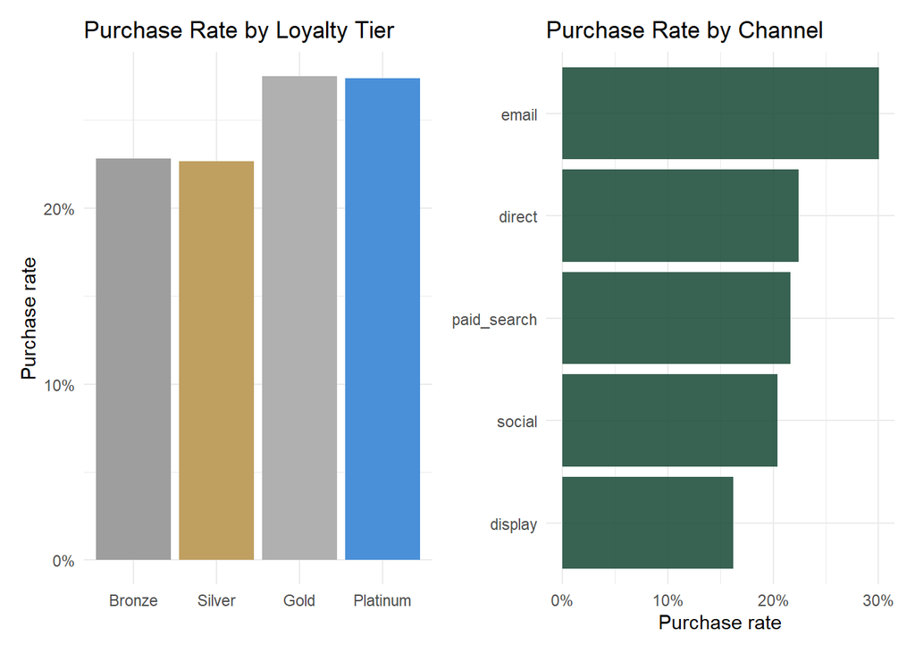

```r
# Purchase rate by loyalty tier and channel
p1 <- campaign_data |>
  group_by(loyalty_tier) |>
  summarise(rate = mean(purchased == "yes")) |>
  ggplot(aes(x = loyalty_tier, y = rate, fill = loyalty_tier)) +
  geom_col(show.legend = FALSE) +
  scale_fill_manual(
    values = c("#9e9e9e", "#C0A060", "#B0B0B0", "#4A90D9")
  ) +
  scale_y_continuous(labels = scales::percent) +
  labs(title = "Purchase Rate by Loyalty Tier", x = NULL, y = "Purchase rate") +
  theme_minimal(base_size = 11)

p2 <- campaign_data |>
  group_by(channel) |>
  summarise(rate = mean(purchased == "yes")) |>
  ggplot(aes(x = reorder(channel, rate), y = rate)) +
  geom_col(fill = "#154734", alpha = 0.85) +
  scale_y_continuous(labels = scales::percent) +
  coord_flip() +
  labs(title = "Purchase Rate by Channel", x = NULL, y = "Purchase rate") +
  theme_minimal(base_size = 11)

p1 + p2
```

### 0.3.2 `avg_order_amt` — Regression Outcome

`avg_order_amt` reflects how basket size varies with customer characteristics and campaign context:

**NoteWhat drives average order value**

**Income** (moderate, r ≈ 0.14): higher-income customers tend to buy more expensive items or fill larger baskets.

**Loyalty tier** (clear gradient): Platinum members shop across more categories and are less price-constrained than Bronze members.

- Bronze ≈ $96 | Silver ≈ $104 | Gold ≈ $119 | Platinum ≈ $144

**Channel** (directional): email and direct traffic drives deliberate, larger purchases; social and display drive impulse buys with smaller baskets.

- Email ≈ $119 | Direct ≈ $111 | Social ≈ $90 | Display ≈ $83

**Device** (meaningful): desktop users complete larger, more intentional purchases; mobile skews toward smaller, faster transactions.

- Desktop ≈ $125 | Tablet ≈ $105 | Mobile ≈ $94

**Cart adds** (strongest behavioral signal, r ≈ 0.15): customers who added more items to their cart predictably complete larger orders.

**Nonlinear interaction**: high discounts increase basket size more for Bronze customers (price-sensitive) than for Platinum (already committed). Trees will find this interaction; linear regression will need it explicitly.

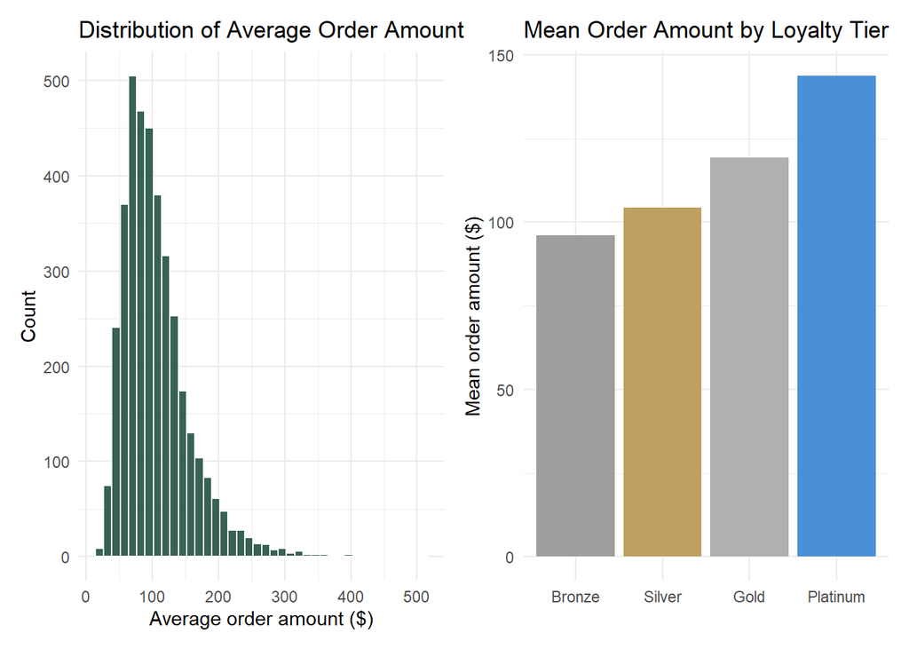

```r
p3 <- ggplot(campaign_data, aes(x = avg_order_amt)) +
  geom_histogram(bins = 40, fill = "#154734", color = "white", alpha = 0.85) +
  labs(
    title = "Distribution of Average Order Amount",
    x = "Average order amount ($)",
    y = "Count"
  ) +
  theme_minimal(base_size = 11)

p4 <- campaign_data |>
  filter(!is.na(avg_order_amt)) |>
  group_by(loyalty_tier) |>
  summarise(mean_order = mean(avg_order_amt)) |>
  ggplot(aes(x = loyalty_tier, y = mean_order, fill = loyalty_tier)) +
  geom_col(show.legend = FALSE) +
  scale_fill_manual(
    values = c("#9e9e9e", "#C0A060", "#B0B0B0", "#4A90D9")
  ) +
  labs(
    title = "Mean Order Amount by Loyalty Tier",
    x = NULL,
    y = "Mean order amount ($)"
  ) +
  theme_minimal(base_size = 11)

p3 + p4
```

# 1 **Train/Test Splits, Recipes, CV Folds**

> Data splits, recipes, and CV folds will be used across all methods.

## 1.1 Splits

```r
set.seed(617)
camp_split <- initial_split(campaign_data, prop = 0.80, strata = purchased)
camp_train <- training(camp_split)
camp_test <- testing(camp_split)

cat("Training rows:", nrow(camp_train), "\n")
```

```
Training rows: 3199
```

```r
cat("Test rows    :", nrow(camp_test), "\n")
```

```
Test rows    : 801
```

```r
cat(
  "Purchase rate (train):",
  round(mean(camp_train$purchased == "yes"), 3),
  "\n"
)
```

```
Purchase rate (train): 0.239
```

```r
cat(
  "Purchase rate (test) :",
  round(mean(camp_test$purchased == "yes"), 3),
  "\n"
)
```

```
Purchase rate (test) : 0.24
```

## 1.2 Recipes

### 1.2.1 Why Trees Need a Different Recipe

> Tree-based models have fundamentally different preprocessing requirements than linear models like Lasso logistic regression.

**NoteWhat trees DON’T need — and why**

- **`step_normalize()`** — Trees split on *rank order*, not *magnitude*. A split at “income > 60,000” produces identical results whether income is on the dollar scale or the normalized (z-score) scale. **Normalization adds no value** and just makes coefficient interpretation harder.
- **`step_log()` on predictors** — Logarithm is a monotone transformation — it preserves rank order. If the optimal split for `income` in dollar scale is at $60,000, the optimal split in log scale is at log($60,000). The tree finds the same split either way. **No need to transform predictors**.
- **Consequence**: the recipe for trees is simpler and produces more interpretable split values (dollar amounts, raw counts) in the tree output.

### 1.2.2 Classification Recipe

```r
# Classification recipe — simpler than Module 2's Lasso recipe
class_rec <- recipe(
  purchased ~ customer_id +
    age +
    income +
    recency_days +
    freq_12mo +
    avg_order_amt +
    site_visits_30d +
    email_clicks_30d +
    discount_rate_seen +
    cart_adds_30d +
    channel +
    region +
    loyalty_tier +
    device,
  data = camp_train
) |>
  update_role(customer_id, new_role = "ID") |>
  step_impute_median(all_numeric_predictors()) |> # still needed — trees can't handle NA
  step_unknown(all_nominal_predictors()) |> # NEW: handle unseen factor levels
  step_dummy(all_nominal_predictors(), one_hot = TRUE) |> # NEW: one-hot for trees
  step_zv(all_predictors())

class_rec
```

**NoteTwo new recipe steps for tree models**

- **`step_unknown()`** — In production, new data may contain factor levels not seen during training (e.g., a new marketing channel is launched after the model was built). Without handling, this causes a prediction error. `step_unknown()` explicitly encodes unseen levels as a new “unknown” category rather than crashing. This is a production-readiness step that becomes important when models are deployed.
- **`one_hot = TRUE` in `step_dummy()`** — Standard dummy encoding creates $k - 1$ columns per factor (dropping one reference level) to avoid multicollinearity in linear models. Trees have no multicollinearity problem — they can split on any column independently.
  - Using `one_hot = TRUE` creates all $k$ columns, which sometimes helps trees find better splits by having each category available as a direct split candidate.
  - For example, with `one_hot = TRUE` the tree can split directly on `channel_email == 1` rather than inferring the email effect from the remaining categories.

### 1.2.3 Regression Recipe

```r
# Regression recipe: predict avg_order_amt
# log-transform the OUTCOME (not predictors) to handle right skew
reg_rec <- recipe(
  avg_order_amt ~ customer_id +
    age +
    income +
    recency_days +
    freq_12mo +
    site_visits_30d +
    email_clicks_30d +
    discount_rate_seen +
    cart_adds_30d +
    channel +
    region +
    loyalty_tier +
    device,
  data = camp_train
) |>
  update_role(customer_id, new_role = "ID") |>
  step_impute_median(all_numeric_predictors()) |>
  step_unknown(all_nominal_predictors()) |>
  step_mutate(avg_order_amt = log(avg_order_amt)) |> # log-transform OUTCOME
  step_dummy(all_nominal_predictors(), one_hot = TRUE) |>
  step_zv(all_predictors())
```

**NoteWhy log-transform the outcome but not the predictors?**

- `avg_order_amt` is right-skewed — a few very large orders pull the distribution out. For regression trees, the split criterion is **RSS (Residual Sum of Squares)**: the algorithm finds the split that minimizes the total squared deviation from the group mean within each node.
- Squared errors punish large outliers heavily — a single $500 order can disproportionately influence which split is chosen. Log-transforming the outcome compresses the scale, reducing the leverage of outliers on split decisions and producing a more balanced tree.

**Note** that predictions will be on the log scale — you need to **`exp()`** them to get back to dollar amounts.

- We do **not** log-transform the predictors because (as explained above) trees are rank-order invariant — monotone predictor transforms have no effect on splits.

## 1.3 Cross-Validation Folds

```r
set.seed(2025)
camp_folds <- vfold_cv(camp_train, v = 10, strata = purchased)
camp_folds
```

| splits | id |
| --- | --- |
|  | Fold01 |
|  | Fold02 |
|  | Fold03 |
|  | Fold04 |
|  | Fold05 |
|  | Fold06 |
|  | Fold07 |
|  | Fold08 |
|  | Fold09 |
|  | Fold10 |

# 2 **Decision Trees**

A decision tree is a **non-parametric model** that recursively partitions the predictor space into a set of rectangular, non-overlapping regions. For any new observation, the tree traces a path from top to bottom through a series of binary (yes/no) split questions (e.g., *“Is `cart_adds_30d`* $\ge 2$?”) until it lands in a final region, where it assigns a prediction.

## 2.1 Conceptual Background

### 2.1.1 Key Terminology

- **Root Node:** The topmost node in the tree representing the entire dataset before any splits occur.
- **Internal (Decision) Node:** A node that splits into two child nodes based on a specific threshold of a single predictor variable.
- **Child Node / Parent Node:** When a node splits, the original node is the *parent*, and the resulting sub-nodes are the *children*.
- **Terminal Node (Leaf):** A final node at the bottom of the tree with no further splits. All observations falling into a leaf receive the same prediction:
  - **Classification:** The majority class (or class proportions) in that leaf.
  - **Regression:** The mean target value ($\bar{y}$) of training points in that leaf.
- **Splitting Rule:** The specific criterion (e.g., Gini impurity or RSS) used to determine the best variable and threshold for dividing data at a node.
- **Pruning:** The process of trimming back fully-grown branches to reduce model complexity and prevent overfitting.

### 2.1.2 How Decision Trees Work

A decision tree recursively splits the training data into regions by asking a series of binary questions: “Is `cart_adds_30d` ≥ 2?” → yes/no, then “Is `recency_days` < 30?” → yes/no, and so on.

#### 2.1.2.1 A. Classification Trees (Gini Impurity)

Splits are selected to minimize the **Gini Impurity** ($G$) across the child nodes:

$$G = 1 - \sum_{k=1}^{K} \hat{p}_{mk}^2$$

Where $\hat{p}_{mk}$ is the proportion of training observations in node $m$ belonging to class $k$.

**NoteInterpreting Gini Impurity**

- $G = 0$ (Completely Pure): Every customer in the node belongs to the exact same class.
- $G \approx 0.5$ (Maximum Impurity for 2 Classes): Class proportions are split evenly ($50/50$).
- The algorithm chooses the split that yields the largest **reduction in weighted Gini impurity** when comparing the parent node to its two child nodes.

#### 2.1.2.2 B. Regression Trees (Residual Sum of Squares)

For continuous outcomes, splits are selected to minimize the **Residual Sum of Squares (RSS)**:

$$\text{RSS} = \sum_{m=1}^{M} \sum_{i \in R_m} (y_i - \bar{y}_{R_m})^2$$

Where $\bar{y}_{R_m}$ is the average response value of training points in region $R_m$.

### 2.1.3 Controlling Tree Complexity (Hyperparameters)

**WarningWhy a single deep tree overfits**

- A fully grown tree will keep splitting until every leaf contains a single training observation — achieving 100% training accuracy but completely memorizing noise.
- This is the same overfitting problem we saw with KNN at k=1 in Module 5.
- The solution is **pruning**: limiting tree complexity via the `cost_complexity` (cp) hyperparameter, which adds a penalty for each additional leaf node.

Unconstrained decision trees will continue splitting until every leaf is completely pure, leading to severe **overfitting** (high variance). In `tidymodels` (via the `rpart` engine), three key hyperparameters control tree growth:

1. **Tree Depth (`tree_depth`):** The maximum length of any path from the root node to a leaf node.
2. **Minimum Split Size (`min_n`):** The minimum number of training observations required in a node for a split to be attempted.
3. **Cost-Complexity Parameter (`cost_complexity` /** $\alpha$): A penalty factor that penalizes larger trees. The algorithm minimizes:
   $$\text{Cost (or Tree Score)} = \text{Error} + \alpha \times (\text{Number of Leaves})$$
   - $\text{Cost}$ is Tree score.
   - $\text{Error}$ is SSR in Regression trees
   - The more the leaves, the greater the penalty
   - $\alpha$ is a tuning parameter, also called Cp.
     - $\alpha = 0$: We will get unpruned, full-size tree; complex tree.
     - Higher $\alpha$: Smaller, simpler tree with fewer leaves.

**TipFeature Scaling & Categorical Variables**

Decision trees evaluate variables **one at a time** (monotonic splits), which gives them two major advantages:

- **No Scaling Required:** Decision trees are completely invariant to monotonic transformations. Normalizing or standardizing features (e.g., `step_normalize()`) does **not** change tree performance.
- **Missing Values & Outliers:** Trees naturally accommodate non-linear relationships and are robust to severe feature outliers.

## 2.2 Clasification Tree

### 2.2.1 Fitting a Classification Tree

```r
tree_spec <- decision_tree(
  cost_complexity = 0.001, # cp: penalty per leaf — smaller = deeper tree
  tree_depth = 10, # maximum depth allowed
  min_n = 20 # minimum observations per node to allow a split
) |>
  set_engine("rpart") |>
  set_mode("classification")

tree_wf <- workflow() |>
  add_recipe(class_rec) |>
  add_model(tree_spec)

tree_fit <- fit(tree_wf, data = camp_train)
```

### 2.2.2 Visualizing the Tree

[figure not shown]

```r
tree_fit |>
  extract_fit_engine() |>
  rpart.plot(
    type = 4,
    extra = 104, # show class probability + % of observations
    box.palette = "GnBu",
    shadow.col = "gray",
    nn = TRUE,
    main = "Decision Tree — Purchase Prediction"
  )
```

**NoteHow to read the tree**

Each node shows three numbers: the **predicted class** (yes/no), the **probability of “yes”**, and the **percentage of training observations** that reach that node.

- **Root node** (top): the starting point — all training data, predicting the majority class at the overall response rate
- **Internal nodes**: each shows the split condition (e.g., `cart_adds_30d < 2`); left branch = TRUE, right branch = FALSE
- **Leaf nodes** (bottom): terminal predictions — the class and probability assigned to any new customer who follows that path through the tree

The first few splits reveal the most important predictors — the algorithm chose them because they produce the largest Gini reduction.

### 2.2.3 Fit Output

```
> tree_fit |>
+   extract_fit_engine()
n= 3199

node), split, n, loss, yval, (yprob)
      * denotes terminal node

   1) root 3199 764 no (0.23882463 0.76117537)
     2) cart_adds_30d>=1.5 789 355 no (0.44993663 0.55006337)
       4) recency_days< 26.5 356 147 yes (0.58707865 0.41292135)
         8) email_clicks_30d>=1.5 208  64 yes (0.69230769 0.30769231)
          16) site_visits_30d>=4.5 57   5 yes (0.91228070 0.08771930) *
          17) site_visits_30d< 4.5 151  59 yes (0.60927152 0.39072848)
            34) channel_email>=0.5 58  11 yes (0.81034483 0.18965517)
              68) site_visits_30d>=1.5 38   3 yes (0.92105263 0.07894737) *
              69) site_visits_30d< 1.5 20   8 yes (0.60000000 0.40000000)
               138) age< 43.5 9   1 yes (0.88888889 0.11111111) *
               139) age>=43.5 11   4 no (0.36363636 0.63636364) *
            35) channel_email< 0.5 93  45 no (0.48387097 0.51612903)
              70) freq_12mo>=3.5 32   8 yes (0.75000000 0.25000000) *
              71) freq_12mo< 3.5 61  21 no (0.34426230 0.65573770)
               142) income>=40431 50  21 no (0.42000000 0.58000000)
                 284) avg_order_amt>=107.56 16   5 yes (0.68750000 0.31250000) *
                 285) avg_order_amt< 107.56 34  10 no (0.29411765 0.70588235)
                   570) channel_social>=0.5 8   3 yes (0.62500000 0.37500000) *
                   571) channel_social< 0.5 26   5 no (0.19230769 0.80769231) *
               143) income< 40431 11   0 no (0.00000000 1.00000000) *
         9) email_clicks_30d< 1.5 148  65 no (0.43918919 0.56081081)
          18) freq_12mo>=3.5 53  19 yes (0.64150943 0.35849057)
            36) age>=35.5 35   8 yes (0.77142857 0.22857143)
              72) discount_rate_seen>=0.075 28   4 yes (0.85714286 0.14285714) *
              73) discount_rate_seen< 0.075 7   3 no (0.42857143 0.57142857) *
            37) age< 35.5 18   7 no (0.38888889 0.61111111) *
          19) freq_12mo< 3.5 95  31 no (0.32631579 0.67368421)
            38) avg_order_amt>=168.505 14   5 yes (0.64285714 0.35714286) *
            39) avg_order_amt< 168.505 81  22 no (0.27160494 0.72839506)
              78) income>=39538.5 61  20 no (0.32786885 0.67213115)
               156) site_visits_30d>=4.5 18   8 yes (0.55555556 0.44444444) *
               157) site_visits_30d< 4.5 43  10 no (0.23255814 0.76744186) *
              79) income< 39538.5 20   2 no (0.10000000 0.90000000) *
```

[output cut: 31 more lines]

```
              91) avg_order_amt< 153.235 73  11 no (0.15068493 0.84931507) *
          23) freq_12mo< 2.5 132  20 no (0.15151515 0.84848485) *
     3) cart_adds_30d< 1.5 2410 409 no (0.16970954 0.83029046)
       6) recency_days< 27.5 1079 276 no (0.25579240 0.74420760)
        12) freq_12mo>=3.5 394 164 no (0.41624365 0.58375635)
          24) cart_adds_30d>=0.5 170  77 yes (0.54705882 0.45294118)
            48) site_visits_30d>=4.5 30   6 yes (0.80000000 0.20000000) *
            49) site_visits_30d< 4.5 140  69 no (0.49285714 0.50714286)
              98) age>=52.5 27   8 yes (0.70370370 0.29629630)
               196) income>=64764.5 16   2 yes (0.87500000 0.12500000) *
               197) income< 64764.5 11   5 no (0.45454545 0.54545455) *
              99) age< 52.5 113  50 no (0.44247788 0.55752212)
               198) site_visits_30d>=2.5 58  26 yes (0.55172414 0.44827586)
                 396) freq_12mo>=4.5 36  12 yes (0.66666667 0.33333333)
                   792) email_clicks_30d>=1.5 15   2 yes (0.86666667 0.13333333) *
```

#### 2.2.3.1 Node 1: The Root Node (The Starting Point)

```
1) root 3199 764 no (0.23882463 0.76117537)
```

- **`1) root`**: This is **Node 1**, the top of the tree representing the entire dataset before any splits occur.
- **`3199` (**$n$): There are **3,199 total observations** in this training set.
- **`764` (loss)**: If we predict the overall majority class for everyone at this step, we make **764 errors** (misclassifications).
- **`no` (`yval`)**: The majority prediction at this node is `"no"`.
- **`(0.23882463 0.76117537)` (`yprob`)**: The proportion of classes in this node:
  - Class 1 (e.g., `"yes"`): **23.88%**
  - Class 2 (e.g., `"no"`): **76.12%** ($3,199 - 764 = 2,435$ actual `"no"` cases; $764 / 3,199 \approx 0.2388$).

#### 2.2.3.2 Node 2: The First Branch (Child Node)

```
2) cart_adds_30d>=1.5 789 355 no (0.44993663 0.55006337)
```

- **`2)`**: This is **Node 2**, the left child node created by answering “Yes” to the split condition.
- **`cart_adds_30d>=1.5`**: The decision rule that routed data into this node. (Customers who had **2 or more cart adds** in the last 30 days).
- **`789` (**$n$): Out of 3,199 customers, **789 met this condition**.
- **`355` (loss)**: Predicting `"no"` for everyone in this group leads to **355 misclassifications**.
- **`no` (`yval`)**: `"no"` remains the predicted majority class label for this node.
- **`(0.44993663 0.55006337)` (`yprob`)**: Notice how the distribution shifted significantly compared to the root node:
  - Class 1 (`"yes"`): Increased from **23.88%** $\rightarrow$ 44.99%
  - Class 2 (`"no"`): Decreased from **76.12%** $\rightarrow$ 55.01%

#### 2.2.3.3 Executive Interpretation

> *“At the root level (3,199 total customers), about 76.1% of customers are class ‘no’. The tree selects `cart_adds_30d` as its very first splitting variable. For customers with at least 2 cart additions (`cart_adds_30d >= 1.5`), the probability of being in class ‘yes’ nearly doubles from 23.9% to 45.0%.”*

**TipHow to Identify Sister Nodes**

In `rpart` tree printouts, child nodes follow a binary numbering convention:

- Node $N$’s left child is $2N$ (e.g., Node 1 $\rightarrow$ **Node 2**).
- Node $N$’s right child is $2N + 1$ (e.g., Node 1 $\rightarrow$ **Node 3** for `cart_adds_30d < 1.5`).

### 2.2.4 Reading Business Rules from the Tree

```r
# Extract rules from the tree as text
library(rpart.plot)
tree_fit |>
  extract_fit_engine() |>
  rpart.plot::rpart.rules(cover = TRUE, style = "tall")
```

|  | ..y |  |  |  |  |  |  |  |  |  |  |  |  |  |  |  |  |  |  |  |  |  |  |  |  |  |  |  |  | … |
| --- | --- | --- | --- | --- | --- | --- | --- | --- | --- | --- | --- | --- | --- | --- | --- | --- | --- | --- | --- | --- | --- | --- | --- | --- | --- | --- | --- | --- | --- | --- |
| 352 | 0.00 | when | cart_adds_30d | is | 1.5 | to | 2.5 | & | recency_days | is | 52 | to | 56 | & | freq_12mo | >= |  |  | 2.5 | & | site_visits_30d | >= |  |  | 2.5 |  |  |  |  | … |
| 68 | 0.08 | when | cart_adds_30d | >= |  |  | 1.5 | & | recency_days | < | 27 |  |  |  |  |  |  |  |  | & | site_visits_30d | is | 1.5 | to | 4.5 | & | email_clicks_30d | >= | 1.5 | … |
| 16 | 0.09 | when | cart_adds_30d | >= |  |  | 1.5 | & | recency_days | < | 27 |  |  |  |  |  |  |  |  | & | site_visits_30d | >= |  |  | 4.5 | & | email_clicks_30d | >= | 1.5 | … |
| 138 | 0.11 | when | cart_adds_30d | >= |  |  | 1.5 | & | recency_days | < | 27 |  |  |  |  |  |  |  |  | & | site_visits_30d | < | 1.5 |  |  | & | email_clicks_30d | >= | 1.5 | … |
| 100 | 0.11 | when | cart_adds_30d | < | 0.5 |  |  | & | recency_days | < | 28 |  |  | & | freq_12mo | >= |  |  | 3.5 | & | site_visits_30d | >= |  |  | 3.5 |  |  |  |  | … |
| 404 | 0.11 | when | cart_adds_30d | < | 0.5 |  |  | & | recency_days | < | 28 |  |  | & | freq_12mo | >= |  |  | 5.5 | & | site_visits_30d | < | 3.5 |  |  |  |  |  |  | … |
| 40 | 0.12 | when | cart_adds_30d | >= |  |  | 2.5 | & | recency_days | >= |  |  | 27 |  |  |  |  |  |  | & | site_visits_30d | >= |  |  | 4.5 |  |  |  |  | … |
| 338 | 0.12 | when | cart_adds_30d | >= |  |  | 2.5 | & | recency_days | >= |  |  | 52 | & | freq_12mo | >= |  |  | 1.5 | & | site_visits_30d | < | 4.5 |  |  | & | email_clicks_30d | >= | 1.5 | … |
| 196 | 0.12 | when | cart_adds_30d | is | 0.5 | to | 1.5 | & | recency_days | < | 28 |  |  | & | freq_12mo | >= |  |  | 3.5 | & | site_visits_30d | < | 4.5 |  |  |  |  |  |  | … |
| 792 | 0.13 | when | cart_adds_30d | is | 0.5 | to | 1.5 | & | recency_days | < | 28 |  |  | & | freq_12mo | >= |  |  | 4.5 | & | site_visits_30d | is | 2.5 | to | 4.5 | & | email_clicks_30d | >= | 1.5 | … |

[output cut: 68 more lines]

### 2.2.5 Classification Tree Performance

```r
tree_preds <- augment(tree_fit, new_data = camp_test)

tree_preds |>
  metric_set(accuracy, roc_auc, sens, spec)(
    truth = purchased,
    estimate = .pred_class,
    .pred_yes
  )
```

| .metric | .estimator | .estimate |
| --- | --- | --- |
| accuracy | binary | 0.7740325 |
| sens | binary | 0.4114583 |
| spec | binary | 0.8883415 |
| roc_auc | binary | 0.7606604 |

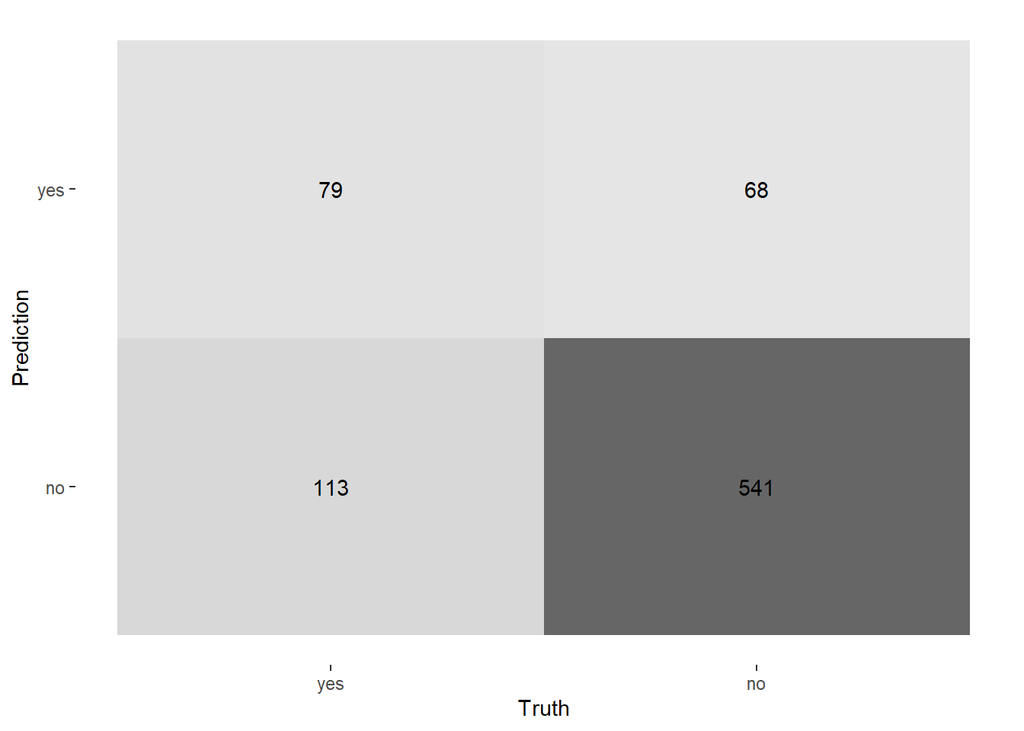

```r
# Confusion matrix
conf_mat(tree_preds, truth = purchased, estimate = .pred_class) |>
  autoplot(type = "heatmap")
```

### 2.2.6 The Overfitting Problem — Shallow vs. Deep Tree

```r
# Compare a very deep tree vs. a pruned tree
fit_tree_cp <- function(cp_val) {
  spec <- decision_tree(cost_complexity = cp_val) |>
    set_engine("rpart") |>
    set_mode("classification")
  wf <- workflow() |> add_recipe(class_rec) |> add_model(spec)
  list(
    train = augment(fit(wf, data = camp_train), new_data = camp_train) |>
      roc_auc(truth = purchased, .pred_yes) |>
      mutate(cp = cp_val, data = "train"),
    test = augment(fit(wf, data = camp_train), new_data = camp_test) |>
      roc_auc(truth = purchased, .pred_yes) |>
      mutate(cp = cp_val, data = "test")
  )
}

cp_vals <- c(0.0001, 0.001, 0.005, 0.01, 0.05)
overfit_results <- map(cp_vals, fit_tree_cp) |>
  map(bind_rows) |>
  bind_rows()

overfit_results |>
  select(cp, data, .estimate) |>
  pivot_wider(names_from = data, values_from = .estimate) |>
  mutate(gap = round(train - test, 4)) |>
  arrange(cp)
```

| cp | train | test | gap |
| --- | --- | --- | --- |
| 1e-04 | 0.8781586 | 0.7633073 | 0.1149 |
| 1e-03 | 0.8468425 | 0.7611479 | 0.0857 |
| 5e-03 | 0.7611692 | 0.7256987 | 0.0355 |
| 1e-02 | 0.6599888 | 0.6552793 | 0.0047 |
| 5e-02 | 0.5000000 | 0.5000000 | 0.0000 |

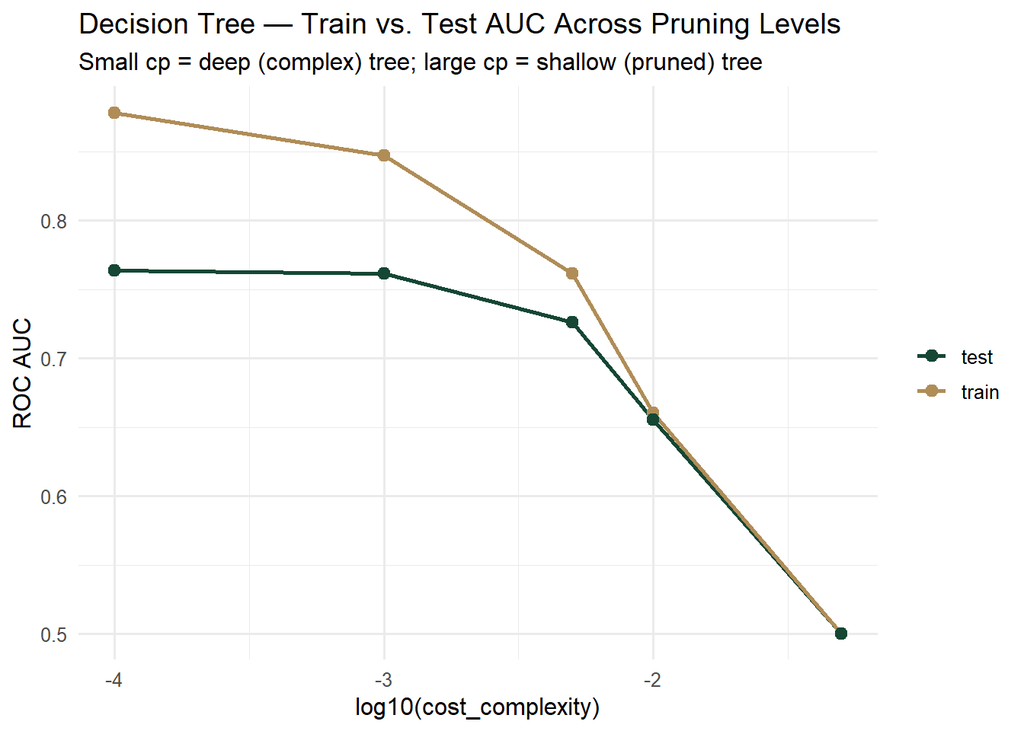

```r
overfit_results |>
  ggplot(aes(x = log10(cp), y = .estimate, color = data, group = data)) +
  geom_line(linewidth = 1) +
  geom_point(size = 2.5) +
  scale_color_manual(values = c(train = "#B08D57", test = "#154734")) +
  labs(
    title = "Decision Tree — Train vs. Test AUC Across Pruning Levels",
    subtitle = "Small cp = deep (complex) tree; large cp = shallow (pruned) tree",
    x = "log10(cost_complexity)",
    y = "ROC AUC",
    color = NULL
  ) +
  theme_minimal(base_size = 12)
```

**NoteReading the overfitting plot**

## 2.3 Regression Tree

### 2.3.1 How Regression Trees Work

While classification trees predict discrete categorical outcomes (e.g., `"yes"` vs. `"no"`), **regression trees** predict a **continuous numerical target variable** (e.g., `revenue`, `income`, or `num_orders`).

Instead of assigning a majority class label at a leaf node, a regression tree calculates the **average target value (**$\bar{y}$) of all training observations that fall into that specific terminal region:

$$\hat{y}_{R_m} = \bar{y}_{R_m} = \frac{1}{n_m} \sum_{i \in R_m} y_i$$

Where $n_m$ is the number of observations in leaf node region $R_m$.

### 2.3.2 Splitting Criterion: Residual Sum of Squares (RSS)

Regression trees recursively partition the feature space by choosing splits that cause the largest reduction in **Residual Sum of Squares (RSS)**:

$$\text{RSS} = \sum_{m=1}^{M} \sum_{i \in R_m} (y_i - \bar{y}_{R_m})^2$$

At each node $m$, the algorithm searches across every available predictor $X_j$ and every possible split value $s$, selecting the pair $(X_j, s)$ that minimizes the combined RSS of the left child region ($R_1$) and right child region ($R_2$):

$$\text{RSS}_{\text{split}} = \sum_{i \in R_1(j,s)} (y_i - \bar{y}_{R_1})^2 + \sum_{i \in R_2(j,s)} (y_i - \bar{y}_{R_2})^2$$

**NoteKey Architectural Property: Step Functions**

A regression tree does **not** fit a smooth, continuous line or curve through data like linear or polynomial regression does.

Instead, it fits a **piecewise constant surface** (a step function). Observations falling into the exact same terminal leaf node receive the exact same predicted value, regardless of where they lie within that feature region.

### 2.3.3 Regression Tree Pruning

#### 2.3.3.1 The Need for Pruning

If left unconstrained, a decision tree will continue splitting data until every leaf node contains only a single observation (or a tiny cluster of points).

While a fully grown, complex tree achieves **near-zero training error** ($\text{RSS} \approx 0$), it severely overfits the training data by fitting to noise rather than signal. This results in **high variance** and poor generalization on unseen test data.

Rather than stopping tree growth early using arbitrary thresholds (which can miss valuable deeper splits), the standard strategy is to:

1. **Grow a large, fully expanded tree** ($T_0$).
2. **Prune it back** to obtain a smaller subtree that balances model complexity and predictive performance.

#### 2.3.3.2 Cost-Complexity Pruning (Weakest-Link Pruning)

The most widely used method for pruning regression trees is **Cost-Complexity Pruning** (also known as $C_p$ or Weakest-Link Pruning).

Instead of evaluating every possible subtree (which is computationally impossible for large trees), Cost-Complexity Pruning indexes a sequence of subtrees using a non-negative **tuning parameter** $\alpha$ (often written as $C_p$ in R).

For a given $\alpha$, the algorithm minimizes the following objective function:

$$\text{Cost Complexity} = \sum_{m=1}^{|T|} \text{RSS}_m + \alpha \cdot |T|$$

Where:

- $\text{RSS}_m$: The Residual Sum of Squares in leaf $m$.
- $|T|$: The total number of terminal leaf nodes in subtree $T$ (representing model complexity).
- $\alpha$ (or $C_p$): The **complexity parameter** that penalizes the tree for having too many leaves.

#### 2.3.3.3 How $\alpha$ ($C_p$) Controls Tree Size

- **When** $\alpha = 0$: There is no penalty for complexity. The algorithm selects the fully grown, unpruned tree ($T_0$).
- **As** $\alpha$ increases: Small branches that yield only minor reductions in RSS are penalized and “collapsed” back into parent nodes.
- **When** $\alpha \to \infty$: The penalty is so severe that the tree is pruned all the way down to a **single root node** (predicting the overall average $\bar{y}$ for everything).

**NoteMathematical Intuition**

As $\alpha$ increases from 0, subtrees are pruned in a deterministic nested sequence:

$$T_0 \supset T_1 \supset T_2 \supset \dots \supset T_{\text{root}}$$

This guarantees that for every value of $\alpha$, there exists a unique optimal subtree to evaluate.

## 2.4 Selecting the Optimal $\alpha$ via Cross-Validation

Because $\alpha$ is a hyperparameter, its optimal value cannot be determined from training data alone. We use $K$-Fold Cross-Validation:

1. **Cross-Validation Split:** Divide the training data into $K$ folds (e.g., $K = 10$).
2. **Evaluate Subtrees:** For each candidate value of $\alpha$, fit the pruned tree on $K-1$ folds and compute the Cross-Validated Root Mean Squared Error ($\text{RMSE}_{\text{CV}}$) on the validation fold.
3. **Pick** $\alpha$: Choose either:
   - **`select_best("rmse")`:** The $\alpha$ that achieves the absolute minimum cross-validated error.
   - **`select_by_one_std_err()` (1-SE Rule):** The simplest tree (highest $\alpha$) whose error is within one standard error of the minimum error. This favors parsimonious, highly interpretable models.

### 2.4.1 Step 1: Baseline Manual Trees (Fixed Hyperparameters)

```r
# 1. Fixed Model Specification
reg_tree_spec <- decision_tree(
  cost_complexity = 0.001, # = tune() for tuning alpha or Cp
  tree_depth = 8,
  min_n = 25
) |>
  set_engine("rpart") |>
  set_mode("regression")

# 2. Workflow Setup
reg_tree_wf <- workflow() |>
  add_recipe(reg_rec) |>
  add_model(reg_tree_spec)

# 3. Fit Model
reg_tree_fit <- fit(reg_tree_wf, data = camp_train)

# 4. Evaluate on test set (predictions are on log scale — back-transform with exp)
reg_tree_preds <- augment(reg_tree_fit, new_data = camp_test) |>
  mutate(
    pred_dollar = exp(.pred), # back-transform to dollars
    actual_dollar = avg_order_amt # already in dollars (not log-transformed in test)
  )

# Baseline Performance Metrics
# Note: actual avg_order_amt in test set is on the original dollar scale
# but the recipe log-transformed it during training —
# we evaluate on the original scale for interpretability
baseline_tree_metrics <- reg_tree_preds |>
  summarise(
    rmse = sqrt(mean((pred_dollar - actual_dollar)^2, na.rm = TRUE)),
    mae = mean(abs(pred_dollar - actual_dollar), na.rm = TRUE),
    r2 = cor(pred_dollar, actual_dollar, use = "complete.obs")^2
  )

baseline_tree_metrics
```

| rmse | mae | r2 |
| --- | --- | --- |
| 49.08212 | 34.9773 | 0.2565643 |

[figure not shown]

```r
reg_tree_fit |>
  extract_fit_engine() |>
  rpart.plot(
    type = 4,
    extra = 1,
    main = "Regression Tree — Average Order Amount (log scale)",
    box.palette = "Blues"
  )
```

### 2.4.2 Step 2: Automated Hyperparameter Tuning via 10-Fold Cross-Validation

Rather than guessing the best value for `cost_complexity` ($\alpha$ / $C_p$), we can mark it as `tune()` and use **10-Fold Cross-Validation** on the training set to find the optimal parameter value automatically.

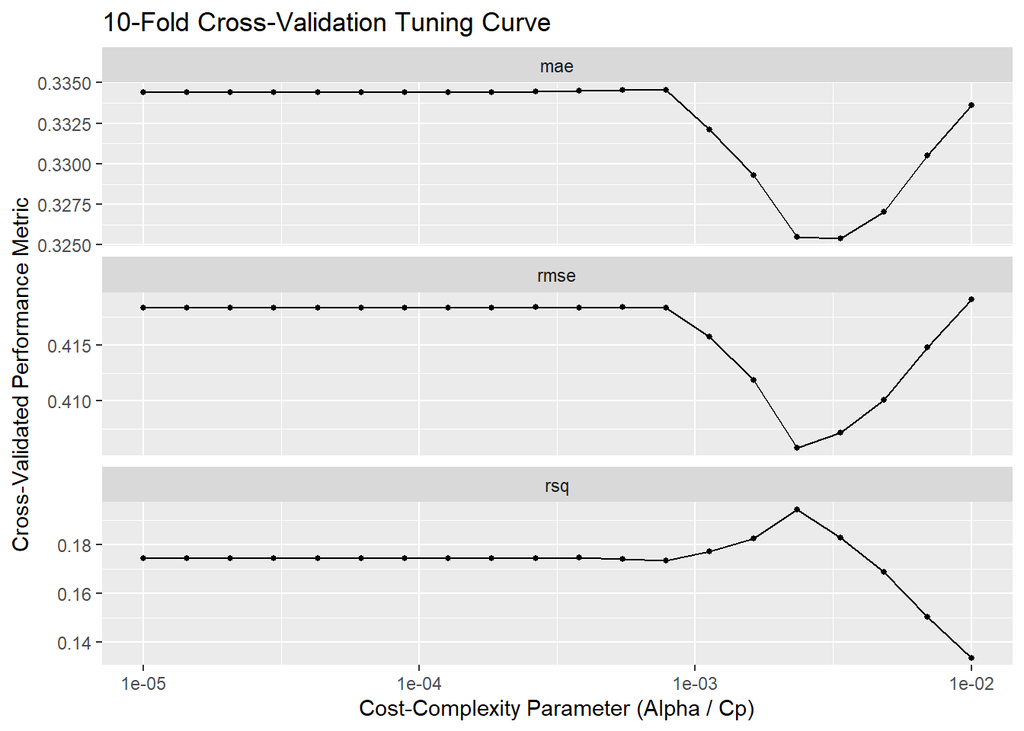

```r
# 1. Model Specification with Tuneable Cost-Complexity
tune_tree_spec <- decision_tree(
  cost_complexity = tune(), # Mark cost_complexity for tuning
  tree_depth = 8,
  min_n = 25
) |>
  set_engine("rpart") |>
  set_mode("regression")

# 2. Workflow Setup
tune_tree_wf <- workflow() |>
  add_recipe(reg_rec) |>
  add_model(tune_tree_spec)

# 3. Create 10-Fold Cross-Validation Resamples
set.seed(2025)
folds <- vfold_cv(camp_train, v = 10)

# 4. Define Grid of Candidate Alpha (Cp) Values
cp_grid <- grid_regular(
  cost_complexity(range = c(-5, -2)), # Evaluates 10^-4 to 10^-1
  levels = 20
)

# 5. Execute 10-Fold Cross-Validation
tune_results <- tune_grid(
  tune_tree_wf,
  resamples = folds,
  grid = cp_grid,
  metrics = metric_set(rmse, rsq, mae),
  control = control_grid(verbose = FALSE, allow_par = TRUE) # optional
)

# 6. Plot the Pruning / Tuning Curve
autoplot(tune_results) +
  labs(
    title = "10-Fold Cross-Validation Tuning Curve",
    x = "Cost-Complexity Parameter (Alpha / Cp)",
    y = "Cross-Validated Performance Metric"
  )
```

**NoteTeaching Moment for Codebook**

When cost_complexity is set too high, `rpart` prunes the tree down to a single root node that predicts a constant mean ($\bar{y}$). As a result, $R^2$ cannot compute a standard deviation and returns NA for extreme $C_p$ values.

### 2.4.3 Step 3: Selecting Best Hyperparameter & Finalizing the Model

We select the best `cost_complexity` value using the **1-Standard Error rule** (`select_by_one_std_err()`), which selects the simplest tree whose performance is within one standard error of the absolute minimum error.

```r
# 1. Select Best Cp using the 1-SE Rule

best_cp_1se <- select_by_one_std_err(
  tune_results,
  metric = "rmse",
  desc(cost_complexity) # prefer larger cp (simpler tree)
)

best_cp <- select_best(tune_results, metric = "rmse")

cat("Chosen Cost-Complexity (Cp):", best_cp_1se$cost_complexity, "\n")
```

```
Chosen Cost-Complexity (Cp): 0.00483293
```

```r
# 2. Finalize Workflow with Tuned Cp
final_tree_wf <- finalize_workflow(tune_tree_wf, best_cp_1se)

# 3. Fit Final Pruned Model on Full Training Data
final_tree_fit <- fit(final_tree_wf, data = camp_train)

# 4. Evaluate Tuned Model on Test Set
final_tree_preds <- augment(final_tree_fit, new_data = camp_test) |>
  mutate(
    pred_dollar = exp(.pred),
    actual_dollar = avg_order_amt
  )

# Compare Metrics against Manual Baseline
tuned_tree_metrics <- final_tree_preds |>
  summarise(
    rmse = sqrt(mean((pred_dollar - actual_dollar)^2, na.rm = TRUE)),
    mae = mean(abs(pred_dollar - actual_dollar), na.rm = TRUE),
    r2 = cor(pred_dollar, actual_dollar, use = "complete.obs")^2
  )

baseline_tree_metrics |>
  mutate(model = "Baseline Tree Metrics") |>
  bind_rows(tuned_tree_metrics |>
              mutate(model = "Tuned Tree Metrics")
            ) |>
  relocate(model, .before = 1)
```

| model | rmse | mae | r2 |
| --- | --- | --- | --- |
| Baseline Tree Metrics | 49.08212 | 34.97730 | 0.2565643 |
| Tuned Tree Metrics | 51.44031 | 35.09913 | 0.1984342 |

**WarningWhy Did the ‘Tuned’ Model Have Worse Test Metrics?**

Looking at the test set metrics, the baseline manual tree ($RMSE = 49.1$) appears to outperform the CV-tuned tree ($RMSE = 51.4$). Why did automated tuning give us a “worse” result?

1. **Sampling Variation in the Test Set:** Cross-validation estimates performance across 10 different folds of the training data. The holdout test set is a single sample. By chance, the manual model’s extra complexity happened to fit the test set’s specific data points better.
2. **The 1-SE Rule Favors Simplicity:** Using `select_by_one_std_err()` intentionally selects a simpler, more pruned tree to guard against overfitting. A simpler tree may yield slightly higher RMSE on a specific test set, but it produces a much cleaner, more robust flowchart for business decision-making.
3. **Manual Guesses Can Be Lucky:** A manually chosen $C_p = 0.001$ happened to work well here, but without cross-validation, we would have no principled way of knowing whether that guess was safe or severely overfitted.

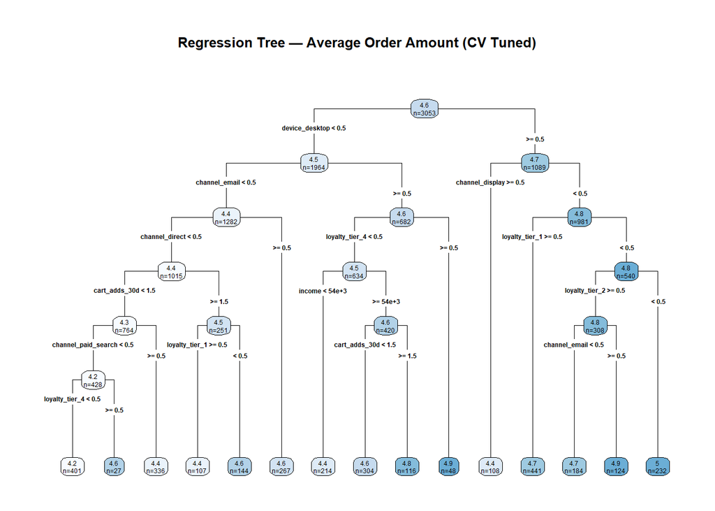

```r
# Visualize the Tuned / Pruned Tree
final_tree_fit |>
  extract_fit_engine() |>
  rpart.plot(
    type = 4,
    extra = 1,
    main = "Regression Tree — Average Order Amount (CV Tuned)",
    box.palette = "Blues"
  )
```

## 2.5 Comparison: Classification Trees vs. Regression Trees

| **Feature** | **Classification Trees** | **Regression Trees** |
| --- | --- | --- |
| **Target Variable (**$Y$) | Categorical (e.g., `Apparel`, `Electronics`) | Continuous (e.g., `Income`, `Orders`) |
| **Prediction at Leaf** | Majority Class Label (or Class Probabilities) | Sample Mean ($\bar{y}$) of observations in leaf |
| **Splitting Metric** | Gini Impurity ($G$) or Entropy | Residual Sum of Squares ($\text{RSS}$) |
| **Prediction Function** | Discrete regional boundary decisions | Piecewise constant step function |
| **Evaluation Metrics** | Accuracy, Sensitivity, Specificity, ROC AUC | RMSE, MAE, $R^2$ |
| **Handling Outliers in** $Y$ | Robust (classes are counted, not averaged) | Sensitive (extreme $y$ values pull the leaf mean $\bar{y}$) |

# 3 **Random Forests**

## 3.1 Conceptual Overview

A single decision tree is **high variance** — small changes in the training data can produce very different trees. The solution is **bagging (Bootstrap AGGregating)**:

1. Draw $B$ bootstrap samples from the training data (sample with replacement)
2. Fit a full decision tree on each bootstrap sample
3. **Average** the predictions across all $B$ trees (regression) or **take a majority vote** (classification)

Averaging over many trees reduces variance dramatically while keeping bias roughly the same — the key insight behind ensemble methods.

**NoteBagging alone is not enough — feature randomness**

If all predictors are strong, every bagged tree will tend to use the same top predictors at its first split. The resulting trees are **highly correlated** — averaging correlated predictions doesn’t reduce variance as much as averaging independent predictions.

**Random forests** fix this with **feature randomness**: at each split, only a random subset of $m$ predictors is considered (controlled by `mtry`). This forces trees to use different predictors, de-correlating them and producing larger variance reduction when averaged.

Typical default: $m = \sqrt{p}$ for classification, $m = p/3$ for regression.

### 3.1.1 How Rows and Trees Relate in a Random Forest

Think of your dataset as a large spreadsheet:

- **Rows (**$N$): Individual observations in your training dataset (e.g., $N = 3,200$ customers).
- **Columns (**$p$): Features/predictors describing each row (e.g., `age`, `income`, `recency`).
- **Trees (**$B$): Complete, individual decision trees built inside the forest (e.g., $B = 500$ trees).

When you build a Random Forest with 500 trees (`trees = 500`), you are **not** matching 1 row to 1 tree. Instead, every single tree is trained on roughly $N$ rows sampled from your dataset:

```
Full Dataset (e.g., 1,000 rows)
                                          │
            ┌─────────────────────────────┼─────────────────────────────┐
            ▼                             ▼                             ▼
    Bootstrap Sample 1            Bootstrap Sample 2            Bootstrap Sample 500
   (~1,000 rows, sampled         (~1,000 rows, sampled         (~1,000 rows, sampled
     with replacement)             with replacement)             with replacement)
            │                             │                             │
            ▼                             ▼                             ▼
        [ Tree 1 ]                    [ Tree 2 ]                   [ Tree 500 ]
  (Full decision flowchart)     (Full decision flowchart)     (Full decision flowchart)
```

### 3.1.2 From One Tree to Many: Bagging (Bootstrap Aggregating)

A single decision tree is notorious for having **high variance**: small perturbations in the training data can alter the root split and result in a completely different tree structure.

To overcome this instability, we turn to an ensemble method called **Bagging (Bootstrap AGGregating)**:

1. **Bootstrap Sampling:** Draw $B$ independent bootstrap samples from the training dataset (sampling $N$ observations *with replacement*).
2. **Parallel Fitting:** Fit an unpruned, deep decision tree to each bootstrap sample.
3. **Aggregating Predictions:** Combine the predictions across all $B$ trees:
   - **Regression:** Compute the average prediction: $\hat{f}_{\text{bag}}(x) = \frac{1}{B} \sum_{b=1}^B \hat{f}^b(x)$
     - $x$ = Input feature vector: e.g., a set of customer characteristics
     - $\hat{f}^b(x)$ = Prediction of Tree *b*
     - $\hat{f}_{\text{bag}}(x)$ = Final Bagged Estimate, which is the aggregated, overall ensemble prediction for observation $x$.
   - **Classification:** Take the majority vote (or average predicted class probabilities).

**NoteRegression vs. Classification**

- For Regression (what this formula shows): The final prediction $\hat{f}_{\text{bag}}(x)$ is the continuous average of all $B$ numeric outputs.
- For Classification: Rather than averaging continuous values, each tree votes for a discrete class label, and $\hat{f}_{\text{bag}}(x)$ represents the majority vote (or the average predicted probability across all $B$ trees).

#### 3.1.2.1 Why Bagging Works: The Mathematics of Variance Reduction

If we have $B$ independent and identically distributed (i.i.d.) random variables each with variance $\sigma^2$, the variance of their average is:

$$\text{Var}\left(\frac{1}{B} \sum_{b=1}^B X_b\right) = \frac{\sigma^2}{B}$$

- $B$: The total number of trees in your ensemble (e.g., $B = 500$).
- $b$: The index for a specific tree, where $b = 1, 2, \dots, B$.
- $X_b$: The output/prediction of tree $b$ for a given observation $x$ (often written as $\hat{f}^b(x)$ in textbook notation).
- $\frac{1}{B} \sum_{b=1}^B X_b$: The average prediction across all $B$ trees in the ensemble (the Bagged / Random Forest estimate).
- $\sigma^2$: The variance of a single individual decision tree ($\text{Var}(X_b) = \sigma^2$).

As $B$ grows large, variance approaches zero. However, because bagged trees are trained on overlapping bootstrap samples from the same dataset, they are **correlated** (with pair-wise correlation $\rho > 0$). The true variance of an ensemble average is:

$$\text{Var}(\text{Ensemble}) = \rho \sigma^2 + \frac{1 - \rho}{B} \sigma^2$$

As $B \to \infty$, the second term drops to zero, but the first term ($\rho \sigma^2$) remains. **If trees are highly correlated (**$\rho$ is large), bagging offers limited variance reduction.

### 3.1.3 De-Correlating Trees: The Random Forest Breakthrough

If a dataset has one or two dominant predictors (e.g., `income` or `recency_days`), **every single bagged tree will select that dominant predictor for its root split**. Consequently, all trees in the bagged ensemble look almost identical ($\rho \approx 1$).

**Random Forests** fix this bottleneck by adding **feature randomness (sub-space sampling)** at every split:

**NoteThe Key Difference: Split-Level Feature Subsampling**

When building each tree, at **every individual split**, the algorithm randomly draws a candidate subset of $m$ features from the total $p$ available features ($m < p$). The tree is forced to choose the best split **only among those** $m$ candidates.

- **Classification Default:** $m = \sqrt{p}$
- **Regression Default:** $m = p/3$

By forcing trees to ignore dominant predictors at many nodes, feature randomness **decorrelates the trees** (lowers $\rho$), unlocking massive variance reduction when averaged.

### 3.1.4 Out-of-Bag (OOB) Error: “Free” Validation

Because each bootstrap sample selects approximately $63.2\%$ of unique observations, the remaining $\sim 36.8\%$ of data points are left out for that specific tree. These are called **Out-of-Bag (OOB)** observations.

- For each observation $i$, we can predict its value using **only the trees where observation** $i$ was OOB.
- Averaging these predictions yields the **OOB Error Rate**, which serves as an unbiased estimate of test error **without needing** $K$-fold cross-validation or a separate validation split.

### 3.1.5 Key Hyperparameters in `tidymodels` (`rand_forest`)

| Math Symbol | Concept | `tidymodels` Argument | Default (`ranger` engine) | Practical Guidance |
| --- | --- | --- | --- | --- |
| $m$ | Candidate features per split | `mtry` | $\sqrt{p}$ (Class) / $p/3$ (Reg) | Primary tuning parameter. Smaller $m \to$ less tree correlation. |
| $B$ | Number of trees | `trees` | $500$ | More is generally better (does not overfit); set high enough for error to stabilize (e.g., $500–1000$). |
| $n_{\text{min}}$ | Min node size for split | `min_n` | $1$ (Class) / $5$ (Reg) | Controls tree depth/growth stopping. Lower values $\to$ deeper trees. |

### 3.1.6 Feature Importance: Peeking Inside the “Black Box”

While individual decision trees produce simple flowchart diagrams, Random Forests aggregate hundreds of trees, sacrificing direct diagram visualizability. To restore interpretability, we measure **Variable Importance**:

1. **Mean Decrease in Impurity (MDI / Gini Importance):** Sums the total reduction in Gini impurity (or RSS) brought about by splits on feature $X_j$, averaged across all trees.
2. **Permutation Importance (OOB Drop):** Randomly shuffles (scrambles) feature $X_j$ in the OOB data and measures how much predictive accuracy degrades. Larger drops in accuracy indicate higher feature importance.

## 3.2 Random Forest with 10 Fold CV

### 3.2.1 Fitting a Random Forest

**Tip**

This code chunk takes a long time to run due to computational complexity. Thus, we recommend running this using parallel processing.

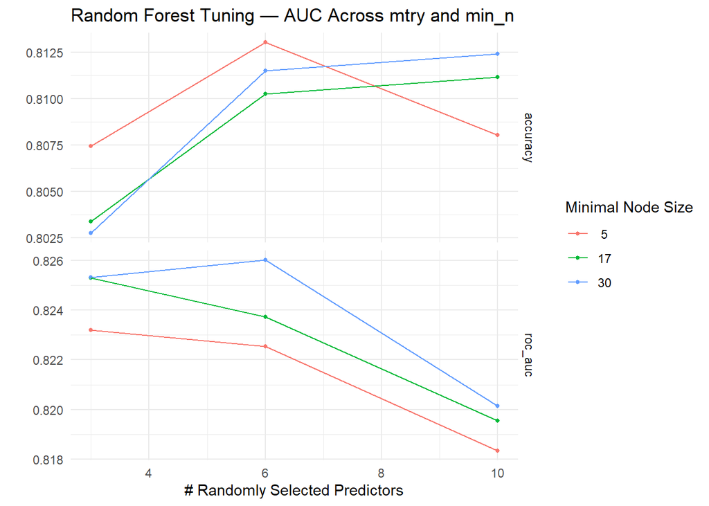

```r
# 1. Parallel processing
library(doParallel)
cl <- makePSOCKcluster(parallel::detectCores() - 1)
registerDoParallel(cl)

# 2. Random Forest Model Specification
rf_spec <- rand_forest(
  trees = 500, # number of trees — more is generally better (diminishing returns)
  mtry = tune(), # number of predictors considered at each split
  min_n = tune() # minimum node size
) |>
  set_engine("ranger", importance = "permutation") |> # enables variable importance
  set_mode("classification")

# 3. Workflow Setup
rf_wf <- workflow() |>
  add_recipe(class_rec) |>
  add_model(rf_spec)

# 4. Turning Grid: small grid for demonstration
set.seed(2025)
rf_grid <- grid_regular(
  mtry(range = c(3, 10)),
  min_n(range = c(5, 30)),
  levels = 3
)

# 5. Tune Grid
rf_tune_results <- tune_grid(
  rf_wf,
  resamples = camp_folds,
  grid = rf_grid,
  metrics = metric_set(roc_auc, accuracy)
)

# 6. Safely Close Cluster
stopImplicitCluster()
stopCluster(cl)

# 7 Plot Results
autoplot(rf_tune_results) +
  labs(title = "Random Forest Tuning — AUC Across mtry and min_n") +
  theme_minimal(base_size = 11)
```

```r
best_rf <- select_best(rf_tune_results, metric = "roc_auc")
best_rf
```

| mtry | min_n | .config |
| --- | --- | --- |
| 6 | 30 | pre0_mod6_post0 |

```r
final_rf_wf <- finalize_workflow(rf_wf, best_rf)
final_rf_fit <- fit(final_rf_wf, data = camp_train)
```

### 3.2.2 Random Forest Performance

```r
rf_preds <- augment(final_rf_fit, new_data = camp_test)

rf_preds |>
  metric_set(accuracy, roc_auc, sens, spec)(
    truth = purchased,
    estimate = .pred_class,
    .pred_yes
  )
```

| .metric | .estimator | .estimate |
| --- | --- | --- |
| accuracy | binary | 0.8077403 |
| sens | binary | 0.3229167 |
| spec | binary | 0.9605911 |
| roc_auc | binary | 0.8046490 |

### 3.2.3 The Effect of `mtry` — Feature Randomness

```r
# Show how AUC changes with mtry at the best min_n
rf_tune_results |>
  collect_metrics() |>
  filter(.metric == "roc_auc") |>
  group_by(mtry, min_n) |>
  summarise(mean_auc = round(mean(mean), 4), .groups = "drop") |>
  arrange(desc(mean_auc))
```

| mtry | min_n | mean_auc |
| --- | --- | --- |
| 6 | 30 | 0.8260 |
| 3 | 17 | 0.8253 |
| 3 | 30 | 0.8253 |
| 6 | 17 | 0.8237 |
| 3 | 5 | 0.8232 |
| 6 | 5 | 0.8225 |
| 10 | 30 | 0.8201 |
| 10 | 17 | 0.8196 |
| 10 | 5 | 0.8183 |

**NoteInterpreting mtry**

A small `mtry` forces each tree to consider fewer predictors — trees become more diverse (less correlated) but individually weaker. A large `mtry` approaches bagging (all predictors available at each split) — trees are stronger individually but more correlated with each other.

The optimal `mtry` balances individual tree quality against ensemble diversity. With ~15 predictors in this dataset, `mtry` values between 3 and 8 typically work best.

### 3.2.4 Out-of-Bag (OOB) Error

```r
# ranger computes OOB error automatically during training
# Extract it from the fitted engine
oob_error <- final_rf_fit |>
  extract_fit_engine() |>
  _$prediction.error

cat("OOB error (misclassification rate):", round(oob_error, 4), "\n")
```

```
OOB error (misclassification rate): 0.1346
```

```r
cat("OOB accuracy                       :", round(1 - oob_error, 4), "\n")
```

```
OOB accuracy                       : 0.8654
```

```r
# Compare to CV accuracy
rf_tune_results |>
  collect_metrics() |>
  filter(.metric == "accuracy") |>
  summarise(cv_accuracy = round(mean(mean), 4))
```

| cv_accuracy |
| --- |
| 0.8089 |

**NoteWhat is OOB error?**

Each bootstrap sample in a random forest leaves out approximately **37% of the training observations** (observations not selected in that particular sample). These *out-of-bag* observations can be used to evaluate each tree without a separate validation set — the OOB error is essentially a free cross-validation estimate computed during training.

### 3.2.5 Variable Importance

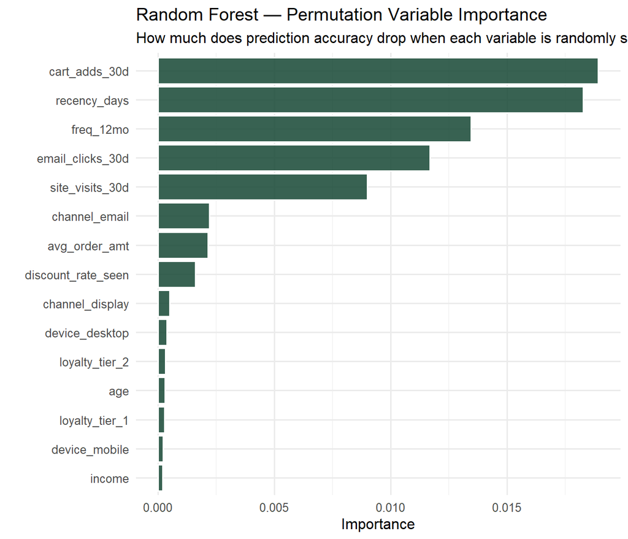

```r
final_rf_fit |>
  extract_fit_parsnip() |>
  vip(
    num_features = 15,
    aesthetics = list(fill = "#154734", color = "white", alpha = 0.85)
  ) +
  labs(
    title = "Random Forest — Permutation Variable Importance",
    subtitle = "How much does prediction accuracy drop when each variable is randomly shuffled?"
  ) +
  theme_minimal(base_size = 12)
```

**NotePermutation importance vs. impurity importance**

The `ranger` engine supports two importance measures:

**Impurity importance** (Gini-based): measures how much each variable decreases weighted Gini impurity across all splits in the forest. Fast to compute but tends to **favor variables with many unique values** (continuous variables and high-cardinality factors) — even if those variables aren’t truly important predictors.

**Permutation importance** (what we use here): for each variable, randomly shuffle its values across all test observations and measure how much prediction accuracy drops. A variable that is truly important will cause a large accuracy drop when shuffled; a noise variable will cause little change. This is more reliable but slower to compute.

We use `importance = "permutation"` in the engine call for this reason — it gives a fairer comparison across predictors with different scales and cardinalities.

### 3.2.6 Model Comparison: Single Tree vs. Random Forest on Prediction Performance

| Metric | Single Decision Tree | Random Forest Ensemble Tuned with 10F CV | Improvement |
| --- | --- | --- | --- |
| **Accuracy** | 0.774 | **0.808** | +4.4% |
| **ROC AUC** | 0.761 | **0.805** | +5.8% |

**TipWhy Random Forest is Superior?**

By combining 500 decorrelated trees via **bagging** and **feature randomness (`mtry`)**, the Random Forest successfully reduced model variance, yielding a significantly higher ROC AUC on holdout test data compared to any individual decision tree.

### 3.2.7 Cost of Random Forest

- **Why use 10-Fold CV?** It fits into the standard `tidymodels` workflow (`tune_grid()`), making it easy to tune hyperparameters using the exact same code structure as Logistic Regression, Decision Trees, or XGBoost.
- **Alternative?** For massive datasets where running 10-Fold CV across a hyperparameter grid takes hours (or days), you can skip $K$-fold CV entirely. You can evaluate candidate models using their built-in **OOB Error**, which requires fitting each candidate forest **only once** instead of 10 times!

**TipSummary**

## 3.3 Random Forest with OBB Tuning

- Instead of re-fitting each forest 10 times across 10 folds, you evaluate each candidate forest exactly ONCE on its own built-in Out-of-Bag (OOB) predictions.
- Because OOB estimation calculates out-of-sample error during training for free, you get 10x speedups (or more) while still finding optimal hyperparameters.

```
Standard 10-Fold CV Search:
Grid Choice 1 ──► [Fit Fold 1] [Fit Fold 2] ... [Fit Fold 10]  (10 Forests fit)
Grid Choice 2 ──► [Fit Fold 1] [Fit Fold 2] ... [Fit Fold 10]  (10 Forests fit)
...

OOB Validation Search:
Grid Choice 1 ──► [Fit 1 Forest on Full Train Data] ──► Extract OOB Error  (1 Forest fit)
Grid Choice 2 ──► [Fit 1 Forest on Full Train Data] ──► Extract OOB Error  (1 Forest fit)
...
```

If you evaluate 20 grid settings:

- **10-Fold CV:** Fits $20 \times 10 = \mathbf{200\text{ forests}}$.
- **OOB Search:** Fits $20 \times 1 = \mathbf{20\text{ forests}}$ (**90% time reduction**).

````markdown
```{r}
#| eval=false

# Function to evaluate OOB error for a single grid row
eval_oob <- function(mtry_val, min_n_val) {
  spec <- rand_forest(trees = 500, mtry = mtry_val, min_n = min_n_val) |>
    set_engine("ranger", oob.error = TRUE) |>
    set_mode("classification")

  wf <- workflow() |>
    add_recipe(class_rec) |>
    add_model(spec)

  fitted_wf <- fit(wf, data = camp_train)

  # Extract the ranger engine object and its OOB prediction error
  ranger_obj <- extract_fit_engine(fitted_wf)

  tibble(
    mtry = mtry_val,
    min_n = min_n_val,
    oob_error = ranger_obj$prediction.error
  )
}

# Iterate over your grid (assuming rf_grid has columns mtry and min_n)
oob_results <- purrr::map2_dfr(rf_grid$mtry, rf_grid$min_n, eval_oob)

# View best hyperparameters based on lowest OOB error
oob_results |> arrange(oob_error)
```
````

### 3.3.2 Method 2: Relying on Robust Defaults (No Search Required)

For many big data applications, **you don’t even need a grid search at all**.

Random Forests are remarkably resilient to hyperparameter choices. Unlike Gradient Boosting (XGBoost) or Neural Networks—which fail completely if tuned poorly—Random Forests perform close to optimal using standard heuristics:

1. **`trees` = 500 to 1,000:** More trees never cause overfitting; performance simply plateaus once the variance reduction reaches diminishing returns.
2. **`mtry` =** $\sqrt{p}$ (classification) or $p/3$ (regression): Default feature subsampling gets you ~95% of peak performance in almost all tabular benchmark tasks.
3. **`min_n` = 1 (classification) or 5 (regression):** Unpruned, deep trees decorrelate best when combined.

```r
# 1. Model Spec (OOB prediction mode)
rf_default_spec <- rand_forest(
  trees = 500,
  mtry = sqrt(15), #3.9
  min_n = 1 # classificaiton default
) |>
  set_engine("ranger", importance = "permutation") |> # Calculates OOB internally
  set_mode("classification")

rf_default_wf <- workflow() |>
  add_recipe(class_rec) |>
  add_model(rf_default_spec)

rf_default_fit <- fit(rf_default_wf, data = camp_train)

# Performance
rf_default_preds <- augment(rf_default_fit, new_data = camp_test)

rf_default_preds |>
  metric_set(accuracy, roc_auc, sens, spec)(
    truth = purchased,
    estimate = .pred_class,
    .pred_yes
  )
```

| .metric | .estimator | .estimate |
| --- | --- | --- |
| accuracy | binary | 0.8064919 |
| sens | binary | 0.2760417 |
| spec | binary | 0.9737274 |
| roc_auc | binary | 0.8019037 |

### 3.3.3 Model Comparison on Single Tree vs. RF with CV vs. RF with Default

| Metric | Single Decision Tree | Random Forest Ensemble Tuned with 10F CV | Random Forest Ensemble (Default) |
| --- | --- | --- | --- |
| **Accuracy** | 0.774 | **0.808** | 0.806 |
| **ROC AUC** | 0.761 | **0.805** | 0.802 |

**TipTakeaway for Class**

Compared with using time-consuming 10 Fold CV-tuned method, the default method reached similar performance faster.

### 3.3.4 Summary Table for Random Forest Tuning Strategy

| **Tuning Strategy** | **How It Works** | **Computation Time** | **Ideal Use Case** |
| --- | --- | --- | --- |
| **10-Fold CV Search** | Fits every candidate $10\times$ across 10 internal validation splits. | **Slowest** ($100\%$ CPU overhead) | Standard datasets; consistent with other `tidymodels` workflows. |
| **OOB Validation Search** | Fits every candidate $1\times$ on full training data; uses built-in OOB error. | **Fast** (~$90\%$ time reduction) | Large datasets; extensive hyperparameter grids. |
| **Robust Defaults** | Skips grid search; uses $m = \sqrt{p}$, $B = 1000$, $n_{\text{min}} = 1$. | **Instant** ($1$ single model fit) | Massive big data streaming / production pipelines. |

# 4 **Boosted Trees**

## 4.1 The Sequential Correction Idea

Random forests train trees **in parallel** — each tree sees a different bootstrap sample but they are independent of each other. **Boosting** takes a fundamentally different approach: trees are trained **sequentially**, with each new tree focusing on the errors made by the current ensemble.

The intuition:

1. Fit a shallow tree to the training data → make predictions
2. Compute the **residuals** (what the ensemble got wrong)
3. Fit the next tree to predict those residuals
4. Add the new tree’s predictions to the ensemble (scaled by `learn_rate`)
5. Repeat $B$ times

Each iteration corrects the mistakes of the previous ensemble — slowly building up a powerful model from many weak ones. This is the core idea of **gradient boosting**.

**NoteThe three key hyperparameters**

**`trees`** — how many sequential trees to fit. More trees = more correction of errors, but also more risk of overfitting if `learn_rate` is too high.

**`learn_rate`** (shrinkage) — how much each tree’s contribution is scaled before adding to the ensemble. Small `learn_rate` (e.g., 0.01) learns slowly, requires more trees, but generalizes better. Large `learn_rate` (e.g., 0.3) learns fast but can overshoot.

**`tree_depth`** — how deep each individual tree is. Boosting typically uses **shallow trees** (depth 1–6), unlike random forests which use full-depth trees. Shallow trees are weak learners — but boosting combines many of them into a strong ensemble. Deeper trees can model more complex interactions per step but increase overfitting risk.

# 5 **AdaBoost** (Adaptive Boosting)

## 5.1 What is AdaBoost?

While Random Forests build hundreds of deep, independent trees in **parallel** (bagging), AdaBoost builds a chain of simple decision trees in **sequence** (boosting).

### 5.1.1 The Core Mechanics

1. **Start with Equal Weights:** Every observation in the training set starts with an equal weight.
2. **Train a Weak Learner:** Train a very simple model—typically a **decision stump** (a decision tree with only one split/depth of 1). A stump is a “weak learner” because it performs only slightly better than random guessing.
3. **Adapt Weights Based on Errors:**
   - Observations that the stump **misclassified** get their weights **increased** (boosted).
   - Observations that were correctly classified get their weights decreased.
4. **Repeat:** The next stump is trained on the re-weighted dataset, forcing it to pay special attention to the hard-to-predict observations.
5. **Combine Predictions:** The final prediction is a **weighted vote** of all stumps. Stumps with lower overall error rates get a stronger vote in the final decision.

```
[ Stump 1 ] ──► Misclassified rows weighted UP ──► [ Stump 2 ] ──► Misclassified rows weighted UP ──► [ Stump 3 ] ...
```

## 5.2 Is AdaBoost “Better” Than Random Forest?

Short answer: Neither is strictly “better”—they trade off bias and variance differently.

### 5.2.1 Why AdaBoost Can Beat Random Forest

- **Lower Bias:** Because each tree focuses specifically on what previous trees got wrong, boosting can fit complex, non-linear boundaries that a Random Forest might smooth over.
- **Parsimony:** AdaBoost often achieves high accuracy with fewer splits overall than an unpruned forest.

### 5.2.2 Why Random Forest Often Beats AdaBoost in Practice

- **Sensitivity to Noise and Outliers:** Because AdaBoost exponentially increases the weight of misclassified points, an outlier or mislabeled data point will get huge weight. The algorithm can become obsessed with fitting noisy observations, leading to **severe overfitting**.
- **Parallelization:** Random Forest trains all 500 trees simultaneously across CPU cores. AdaBoost must wait for Stump 1 to finish before Stump 2 can evaluate errors.

# 6 **Gradient Boosting**: Learning from Residuals

While **AdaBoost** adjusts row weights to force subsequent trees to focus on hard cases, **Gradient Boosting (GBM)** takes a more direct mathematical approach: each new tree is trained to predict the **residuals** (the leftover prediction errors) of the ensemble built so far.

- Gradient boosting for regression
- Gradient boosting for classification

## 6.1 The Core Intuition: Golfing Toward the Target

Think of Gradient Boosting like a golfer trying to hit a ball into a hole:

1. **First Shot (**$\hat{f}_1$): You take a big drive toward the hole. You miss by 50 yards short and 10 yards left. This error is your **residual**.
2. **Second Shot (**$\hat{f}_2$): Instead of starting over at the tee, you walk up to your ball and swing **only to cover the remaining 50 yards short and 10 yards left**.
3. **Third Shot (**$\hat{f}_3$): Your second shot gets close, leaving you only 3 feet short. You tap the ball 3 feet forward.

Your final position is the **sum of all shots**:

$$\text{Final Prediction} = \text{Shot}_1 + \text{Shot}_2 + \text{Shot}_3 + \dots$$

## 6.2 Step-by-Step Algorithm (Regression Example)

To predict a continuous target variable $y$ using features $X$:

### 6.2.1 Step 1: Initialize with a Baseline Constant

Start with a single constant prediction $\hat{f}_0(x)$—typically the mean of $y$ for all observations:

$$\hat{f}_0(x) = \bar{y}$$

### 6.2.2 Step 2: Sequentially Fit Trees to Residuals

For $m = 1$ to $M$ (where $M$ is the total number of trees):

1. **Compute Pseudo-Residuals:** Calculate the difference between actual targets $y_i$ and current ensemble predictions $\hat{f}_{m-1}(x_i)$ for every observation $i$:
   $$r_{i,m} = y_i - \hat{f}_{m-1}(x_i)$$
2. **Fit a Decision Tree:** Fit a small, shallow decision tree $h_m(x)$ (typically 2 to 6 splits) using $X$ as predictors and **the residual** $r_{i,m}$ as the target variable.
3. **Update the Ensemble with a Learning Rate (**$\eta$): Add the new tree’s predictions scaled by a learning rate $\eta$ ($0 < \eta \le 1$, often $0.01$ to $0.1$):
   $$\hat{f}_m(x) = \hat{f}_{m-1}(x) + \eta \cdot h_m(x)$$

### 6.2.3 Step 3: Output the Final Ensemble Model

After fitting $M$ trees, the final prediction is:

$$\hat{f}(x) = \hat{f}_0(x) + \eta \sum_{m=1}^M h_m(x)$$

## 6.3 Why the Name *Gradient* Boosting?

When using squared error loss $L(y, \hat{y}) = \frac{1}{2}(y - \hat{y})^2$, the negative gradient of the loss function with respect to the prediction is:

$$-\frac{\partial L}{\partial \hat{y}} = y - \hat{y} = \text{Residual}$$

Fitting a tree to $y - \hat{y}$ is mathematically equivalent to taking a step in the direction of the **steepest descent (negative gradient)** to minimize overall loss.

**NoteTeaching Moment: Loss Function Versatility**

Because it uses gradient descent, Gradient Boosting works on **any differentiable loss function**:

- **Regression:** Squared error loss ($L_2$) or Absolute error loss ($L_1$, robust to outliers).
- **Classification:** Log-loss / Binary Cross-Entropy.

## 6.4 Key Hyperparameters in Gradient Boosting

Unlike Random Forests—where adding more trees never causes overfitting—**Gradient Boosting can easily overfit if left unchecked**. Tuning requires balancing three primary hyperparameters:

| Parameter | Concept | `tidymodels` Argument | Role in the Ensemble |
| --- | --- | --- | --- |
| $M$ | Number of Boosting Iterations | `trees` | Too few leads to underfitting; too many leads to overfitting. |
| $\eta$ | Shrinkage / Learning Rate | `learn_rate` | Scales the contribution of each tree. Smaller values ($\eta = 0.01–0.1$) require more trees but yield better generalization. |
| $d$ | Tree Depth | `tree_depth` | Controls maximum depth of each shallow tree. Often $d = 2–6$ (shallow trees control variance). |

## 6.5 Summary Comparison: Bagging vs. Boosting Comparison

| Property | Random Forest | Gradient Boosting |
| --- | --- | --- |
| **Tree Construction** | Parallel (Independent) | Sequential (Chained) |
| **Individual Tree Size** | Deep, unpruned trees | Very shallow trees (stumps / small depth) |
| **Primary Goal** | Reduces **Variance** | Reduces **Bias** |
| **Risk of Overfitting** | Low (adding trees stabilizes error) | High (requires early stopping / tuning $M$) |
| **Tuning Sensitivity** | Low (defaults work well) | High (requires tuning `trees`, `learn_rate`, `tree_depth`) |

## 6.6 Gradient Boosting vs. Adaboost

**Gradient Boosting is a generalization and upgrade of AdaBoost.** While AdaBoost was a brilliant proof-of-concept for sequential learning, Gradient Boosting replaced AdaBoost’s specific “reweighting” trick with a flexible mathematical framework based on gradient descent.

```
AdaBoost Strategy: [Tree 1] ──► Find wrong rows ──► Increase row WEIGHTS ──► [Tree 2 fits weighted data]  Gradient Boosting Strategy: [Tree 1] ──► Calculate errors (y - y_hat) ──► [Tree 2 fits directly to RESIDUALS]
```

### 6.6.1 AdaBoost (Adaptive Boosting)

- **The Mechanism:** Starts with equal weights for every row. After fitting a tree (usually a 1-split decision stump), it **increases the weights of misclassified rows** and decreases the weights of correct ones.
- **The Next Tree:** The next stump is forced to pay more attention to the heavily weighted “hard” rows.
- **Voting:** Final predictions are made via a **weighted vote**, where high-accuracy trees get more say than weaker trees.

### 6.6.2 Gradient Boosting (GBM)

- **The Mechanism:** Instead of changing row weights, the next tree is trained to directly predict the **residuals** (the leftover mathematical error $y - \hat{y}$) of all previous trees combined.
- **The Next Tree:** Fits directly to those continuous residual errors.
- **Voting:** Final predictions are made by **adding up the outputs** of all trees scaled by a learning rate ($\eta$).

## 6.7 Is Gradient Boosting “Better” Than AdaBoost

### 6.7.1 A. Robustness to Noise and Outliers (The Major Flaw of AdaBoost)

Because AdaBoost **exponentially increases** the weights of misclassified observations, an outlier or mislabeled data point will quickly dominate the weights. AdaBoost gets “obsessed” with fitting noise, leading to **severe overfitting**.

Gradient Boosting, by contrast, uses differentiable loss functions (like Huber loss or absolute error) that can gracefully down-weight extreme outliers.

### 6.7.2 B. Loss Function Flexibility

- **AdaBoost** is strictly tied to **exponential loss** (for classification) or square error loss variants.
- **Gradient Boosting** works with **any differentiable loss function**. You can use:
  - **MSE (**$L_2$): For standard continuous regression.
  - **MAE (**$L_1$): For median regression (robust to outliers).
  - **Log-Loss / Cross-Entropy:** For binary and multi-class classification.
  - **Poisson / Tweedie:** For count data or insurance claims.

### 6.7.3 C. Capacity to Scale & Complex Patterns

AdaBoost typically relies on **decision stumps** (trees with a depth of 1), which can struggle to capture complex higher-order feature interactions. Gradient Boosting uses shallow trees (depth 3–6), allowing it to model complex interactions while predicting fine-grained residual magnitudes rather than just binary directional corrections.

## 6.8 Core Comparison at a Glance

| **Feature** | **AdaBoost** | **Gradient Boosting (GBM)** |
| --- | --- | --- |
| **Core Idea** | Adjusts row weights based on errors | Fits new trees directly to residuals ($y - \hat{y}$) |
| **Individual Trees** | Very simple stumps (Depth = 1) | Shallow trees (Depth = 2–6) |
| **Optimization Method** | Exponential reweighting | Gradient descent on a loss function |
| **Outlier Sensitivity** | **High** (gets trapped fitting noise) | **Low to Moderate** (controllable via loss function) |
| **Flexibility** | Limited to exponential loss | Any differentiable loss function |
| **Modern Usage** | Rarely used standalone today | Industry standard (via XGBoost, LightGBM, CatBoost) |

# 7 **XGBoost**: eXtreme Gradient Boosting

While standard **Gradient Boosting (GBM)** provided a revolutionary framework for learning from residuals, **XGBoost (eXtreme Gradient Boosting)** took the data science world by storm by redesigning both the **statistical formulation** and the **underlying engineering**.

XGBoost isn’t just a different implementation; it optimizes *how* trees are built, *how* complexity is penalized, and *how* computation is hardware-accelerated.

## 7.1 What Makes XGBoost “eXtreme”?

The primary distinction lies in three pillars: **Regularization**, **Second-Order Optimization**, and **System Engineering**.

## 7.2 Statistical Innovations

### 7.2.1 A. Direct Regularization on Tree Structure

Standard GBM controls model complexity indirectly by limiting tree depth or capping the number of trees. XGBoost explicitly incorporates a **regularization penalty (**$\Omega$) directly into the objective function that the algorithm minimizes at every split:

$$\text{Objective} = \sum_{i=1}^n L(y_i, \hat{y}_i) + \sum_{m=1}^M \Omega(h_m)$$

The penalty term for each tree $\Omega(h)$ is defined as:

$$\Omega(h) = \gamma T + \frac{1}{2} \lambda \sum_{j=1}^T w_j^2 + \alpha \sum_{j=1}^T |w_j|$$

- $T$ (Number of Leaves): $\gamma$ (gamma) penalizes adding new leaf nodes. A split is only allowed if the improvement in loss exceeds $\gamma$ (acting as automated pruning).
- $w_j$ (Leaf Weights): $\lambda$ ($L_2$ Ridge penalty) and $\alpha$ ($L_1$ Lasso penalty) penalize extreme leaf prediction values, smoothing predictions and preventing individual leaves from overfitting to noisy data points.

### 7.2.2 B. Second-Order Taylor Expansion (Gradients + Hessians)

Standard Gradient Boosting relies on first-order derivatives (the direction of error, or gradients). XGBoost uses a **second-order Taylor expansion** to approximate the loss function:

$$L(y_i, \hat{y}_i^{(m)}) \approx L(y_i, \hat{y}_i^{(m-1)}) + g_i w + \frac{1}{2} h_i w^2$$

- $g_i$ (Gradient): The first derivative of the loss function (where the error is heading).
- $h_i$ (Hessian): The second derivative of the loss function (the curvature of the error surface).

**NoteWhy Hessians Matter**

By using the Hessian ($h_i$), XGBoost measures how fast the gradient is changing. This gives the algorithm “Newton-Raphson” step sizes, allowing it to calculate the precise optimal leaf weights $w_j$ in far fewer boosting iterations than standard GBM.

## 7.3 Algorithmic Innovations

### 7.3.1 A. Native Handling of Missing Values (Sparsity Awareness)

In traditional decision trees, missing data (`NA`s) must be imputed before training. XGBoost handles missing values natively:

1. During split evaluation, XGBoost sends all observations with missing values for feature $X$ to the **left child**, calculates the split score, and then sends them to the **right child**.
2. It compares the loss reduction of both directions and learns a **default direction** for missing values at every single node.
3. During inference, if a new observation contains an `NA`, it automatically follows the learned default pathway.

### 7.3.2 B. Feature & Row Subsampling

Borrowing directly from Random Forests, XGBoost supports:

- **Column Subsampling (`colsample_bytree`):** Selects a random subset of features for each tree (equivalent to `mtry`).
- **Row Subsampling (`subsample`):** Trains each tree on a random fraction of rows (without replacement).

This double-subsampling decorrelates sequential trees further and speeds up execution time.

## 7.4 System Engineering: Why It’s Fast

| Feature | Standard GBM | XGBoost |
| --- | --- | --- |
| **Split Finding** | Evaluates all possible split points sequentially across features. | **Exact Greedy** or **Weighted Quantile Sketch** (groups continuous data into histogram bins). |
| **Parallelization** | Sequential only (must wait for previous tree to finish). | Parallelized split finding across feature columns during node creation. |
| **Hardware Efficiency** | Standard memory layout. | **Cache-aware block structure** loads feature data directly into CPU L1/L2 caches. |

## 7.5 Key Hyperparameter Mapping (`tidymodels`)

When implementing XGBoost in R using `boost_tree()` with `engine = "xgboost"`, standard parameters map directly to XGBoost terms:

| Concept | XGBoost Parameter | `tidymodels` Parameter | Description |
| --- | --- | --- | --- |
| **Trees** | `nrounds` / `n_estimators` | `trees` | Total number of sequential trees built. |
| **Learning Rate** | `eta` | `learn_rate` | Step-size shrinkage used to prevent overfitting ($0.01 - 0.3$). |
| **Tree Depth** | `max_depth` | `tree_depth` | Maximum depth of a tree ($3 - 10$). |
| **Min Node Weight** | `min_child_weight` | `min_n` | Minimum sum of instance weight (Hessian) needed in a child node. |
| **Feature Fraction** | `colsample_bytree` | `mtry` | Proportion of features sampled for each tree. |
| **Data Fraction** | `subsample` | `sample_size` | Proportion of training rows sampled for each tree. |
| **Complexity Loss** | `gamma` | `loss_reduction` | Minimum loss reduction required to make a further partition. |

## 7.6 Summary Comparison: Decision Tree Family

| Algorithm | Model Building | Tree Depth | Overfitting Controls | Primary Strengths |
| --- | --- | --- | --- | --- |
| **Single Tree** | Single Pass | Deep / Pruned | Cost-complexity pruning | High interpretability |
| **Random Forest** | Parallel (Bagging) | Deep | Feature randomness (`mtry`) | Low tuning needed; robust variance reduction |
| **Gradient Boosting** | Sequential (Residuals) | Shallow | Learning rate, early stopping | Low bias; adapts to hard cases |
| **XGBoost** | Sequential (Gradients + Hessians) | Shallow / Medium | $L_1$/$L_2$ regularization, $\gamma$ pruning, subsampling | Peak predictive power; blazing speed on huge datasets |

## 7.7 Fitting XGBoost

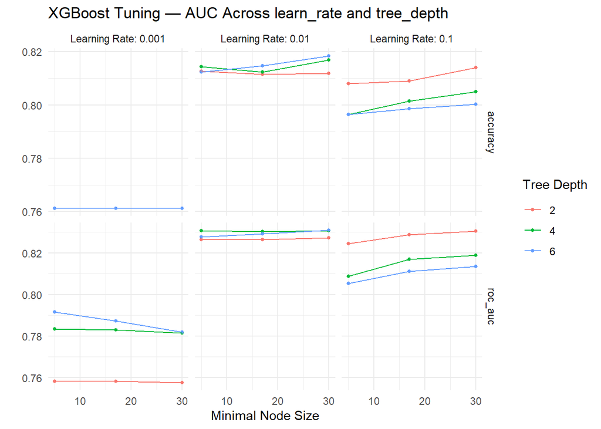

```r
boost_spec <- boost_tree(
  trees = 500,
  tree_depth = tune(),
  learn_rate = tune(),
  min_n = tune()
) |>
  set_engine("xgboost") |>
  set_mode("classification")

boost_wf <- workflow() |>
  add_recipe(class_rec) |>
  add_model(boost_spec)

# Small grid for demonstration
set.seed(2025)
boost_grid <- grid_regular(
  tree_depth(range = c(2, 6)),
  learn_rate(range = c(-3, -1)), # log10 scale: 0.001 to 0.1
  min_n(range = c(5, 30)),
  levels = 3
)

boost_tune_results <- tune_grid(
  boost_wf,
  resamples = camp_folds,
  grid = boost_grid,
  metrics = metric_set(roc_auc, accuracy)
)

autoplot(boost_tune_results) +
  labs(title = "XGBoost Tuning — AUC Across learn_rate and tree_depth") +
  theme_minimal(base_size = 11)
```

```r
best_boost <- select_best(boost_tune_results, metric = "roc_auc")
best_boost
```

| min_n | tree_depth | learn_rate | .config |
| --- | --- | --- | --- |
| 30 | 6 | 0.01 | pre0_mod26_post0 |

```r
final_boost_wf <- finalize_workflow(boost_wf, best_boost)
final_boost_fit <- fit(final_boost_wf, data = camp_train)
```

## 7.8 Boosted Tree Performance

```r
boost_preds <- augment(final_boost_fit, new_data = camp_test)

boost_preds |>
  metric_set(accuracy, roc_auc, sens, spec)(
    truth = purchased,
    estimate = .pred_class,
    .pred_yes
  )
```

| .metric | .estimator | .estimate |
| --- | --- | --- |
| accuracy | binary | 0.8114856 |
| sens | binary | 0.3958333 |
| spec | binary | 0.9425287 |
| roc_auc | binary | 0.8174090 |

## 7.9 The `learn_rate` × `trees` Tradeoff

```r
# Fit models with different learn_rate values at fixed tree_depth
fit_boost_lr <- function(lr) {
  spec <- boost_tree(
    trees = 300,
    learn_rate = lr,
    tree_depth = best_boost$tree_depth,
    min_n = best_boost$min_n
  ) |>
    set_engine("xgboost") |>
    set_mode("classification")

  wf <- workflow() |> add_recipe(class_rec) |> add_model(spec)
  fit_obj <- fit(wf, data = camp_train)

  bind_rows(
    augment(fit_obj, new_data = camp_train) |>
      roc_auc(truth = purchased, .pred_yes) |>
      mutate(learn_rate = lr, data = "train"),
    augment(fit_obj, new_data = camp_test) |>
      roc_auc(truth = purchased, .pred_yes) |>
      mutate(learn_rate = lr, data = "test")
  )
}

lr_comparison <- map_dfr(c(0.01, 0.05, 0.10, 0.30), fit_boost_lr)

lr_comparison |>
  select(learn_rate, data, .estimate) |>
  pivot_wider(names_from = data, values_from = .estimate) |>
  mutate(gap = round(train - test, 4)) |>
  arrange(learn_rate)
```

| learn_rate | train | test | gap |
| --- | --- | --- | --- |
| 0.01 | 0.8739811 | 0.8140993 | 0.0599 |
| 0.05 | 0.9204592 | 0.8227713 | 0.0977 |
| 0.10 | 0.9483976 | 0.8139881 | 0.1344 |
| 0.30 | 0.9848087 | 0.7998940 | 0.1849 |

**NoteReading the learn_rate comparison**

Small `learn_rate` (0.01): train and test AUC are close — the model is learning slowly and generalizing well but may need many more trees to reach peak performance.

Large `learn_rate` (0.30): training AUC is very high but test AUC may be lower — the model is taking large steps and overshooting the optimal solution, introducing variance that hurts generalization.

The practical recommendation: **use a small `learn_rate` (0.01–0.05) with more trees**. This is almost always the most reliable combination in marketing applications.

## 7.10 Variable Importance

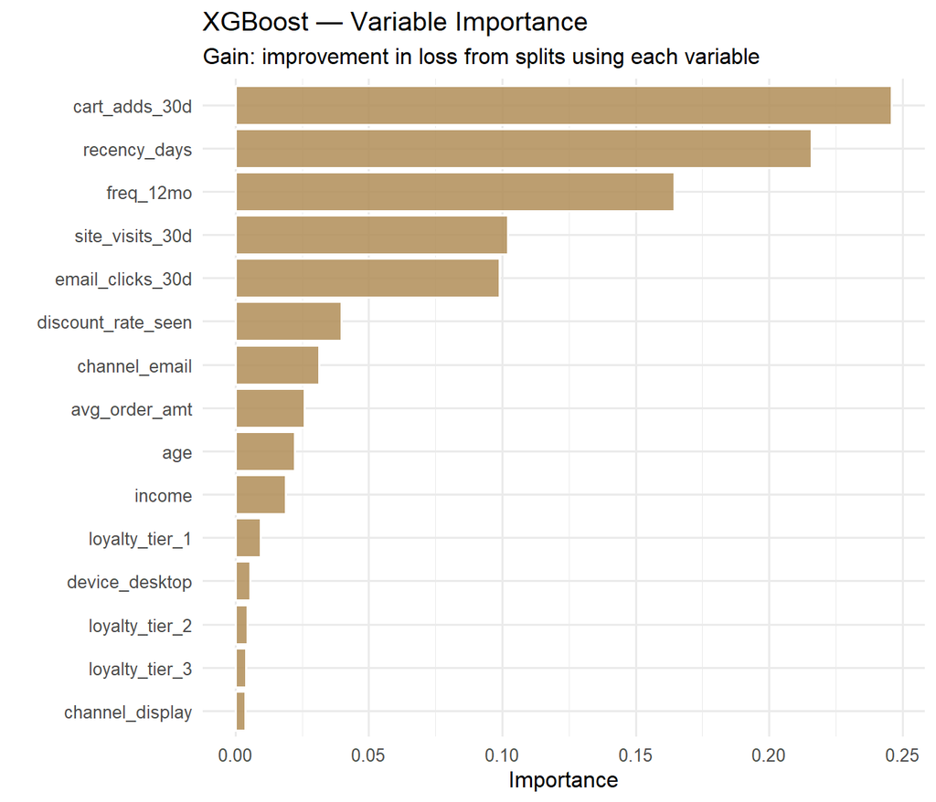

```r
final_boost_fit |>
  extract_fit_parsnip() |>
  vip(
    num_features = 15,
    aesthetics = list(fill = "#B08D57", color = "white", alpha = 0.85)
  ) +
  labs(
    title = "XGBoost — Variable Importance",
    subtitle = "Gain: improvement in loss from splits using each variable"
  ) +
  theme_minimal(base_size = 12)
```

# 8 **Model Comparison**

## 8.1 All Models on the Same Test Set

```r
# Lasso logistic regression baseline (same recipe as Module 2 approach)
lasso_rec <- recipe(
  purchased ~ customer_id +
    age +
    income +
    recency_days +
    freq_12mo +
    avg_order_amt +
    site_visits_30d +
    email_clicks_30d +
    discount_rate_seen +
    cart_adds_30d +
    channel +
    region +
    loyalty_tier +
    device,
  data = camp_train
) |>
  update_role(customer_id, new_role = "ID") |>
  step_impute_median(all_numeric_predictors()) |>
  step_log(income, avg_order_amt, base = 10, offset = 1) |>
  step_normalize(all_numeric_predictors()) |>
  step_ordinalscore(loyalty_tier) |>
  step_dummy(all_nominal_predictors()) |>
  step_zv(all_predictors())

lasso_spec <- logistic_reg(penalty = 0.01, mixture = 1) |>
  set_engine("glmnet") |>
  set_mode("classification")

lasso_wf <- workflow() |> add_recipe(lasso_rec) |> add_model(lasso_spec)
lasso_fit <- fit(lasso_wf, data = camp_train)
lasso_preds <- augment(lasso_fit, new_data = camp_test)

# Combine all test-set results
all_model_metrics <- bind_rows(
  lasso_preds |>
    metric_set(roc_auc, accuracy)(
      truth = purchased,
      estimate = .pred_class,
      .pred_yes
    ) |>
    mutate(model = "Lasso LR (baseline)"),
  tree_preds |>
    metric_set(roc_auc, accuracy)(
      truth = purchased,
      estimate = .pred_class,
      .pred_yes
    ) |>
    mutate(model = "Decision Tree"),
  rf_preds |>
    metric_set(roc_auc, accuracy)(
      truth = purchased,
      estimate = .pred_class,
      .pred_yes
    ) |>
    mutate(model = "Random Forest"),
  boost_preds |>
    metric_set(roc_auc, accuracy)(
      truth = purchased,
      estimate = .pred_class,
      .pred_yes
    ) |>
    mutate(model = "XGBoost")
)

all_model_metrics |>
  filter(.metric == "roc_auc") |>
  select(model, roc_auc = .estimate) |>
  arrange(desc(roc_auc))
```

| model | roc_auc |
| --- | --- |
| Lasso LR (baseline) | 0.8365575 |
| XGBoost | 0.8174090 |
| Random Forest | 0.8046490 |
| Decision Tree | 0.7606604 |

## 8.2 ROC Curves — All Models Overlaid

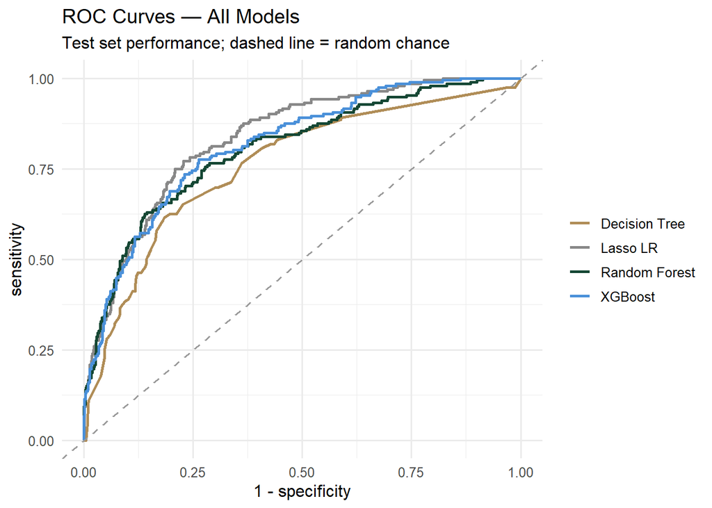

```r
roc_data <- bind_rows(
  lasso_preds |>
    roc_curve(truth = purchased, .pred_yes) |>
    mutate(model = "Lasso LR"),
  tree_preds |>
    roc_curve(truth = purchased, .pred_yes) |>
    mutate(model = "Decision Tree"),
  rf_preds |>
    roc_curve(truth = purchased, .pred_yes) |>
    mutate(model = "Random Forest"),
  boost_preds |>
    roc_curve(truth = purchased, .pred_yes) |>
    mutate(model = "XGBoost")
)

ggplot(roc_data, aes(x = 1 - specificity, y = sensitivity, color = model)) +
  geom_path(linewidth = 0.9) +
  geom_abline(linetype = "dashed", color = "gray60") +
  scale_color_manual(
    values = c(
      "Lasso LR" = "#888888",
      "Decision Tree" = "#B08D57",
      "Random Forest" = "#154734",
      "XGBoost" = "#4A90D9"
    )
  ) +
  labs(
    title = "ROC Curves — All Models",
    subtitle = "Test set performance; dashed line = random chance",
    color = NULL
  ) +
  theme_minimal(base_size = 12)
```

## 8.3 Model Comparison Summary

```r
all_model_metrics |>
  select(model, .metric, .estimate) |>
  pivot_wider(names_from = .metric, values_from = .estimate) |>
  arrange(desc(roc_auc)) |>
  gt() |>
  tab_header(title = "Test Set Performance — All Models") |>
  fmt_number(columns = c(roc_auc, accuracy), decimals = 4)
```

Test Set Performance — All Models

| model | accuracy | roc_auc |
| --- | --- | --- |
| Lasso LR (baseline) | 0.8027 | 0.8366 |
| XGBoost | 0.8115 | 0.8174 |
| Random Forest | 0.8077 | 0.8046 |
| Decision Tree | 0.7740 | 0.7607 |

**NoteWhy ensemble methods typically outperform single trees**

A single decision tree is a **high-variance** model — it can fit the training data well but is sensitive to which particular observations happened to be in the training set. Both random forests and boosting address this:

- **Random forests** reduce variance by averaging many decorrelated trees
- **XGBoost** reduces bias by sequentially correcting prediction errors

The Lasso logistic regression (linear model) provides a useful baseline: if tree methods don’t outperform it, the relationships in the data are likely approximately linear and the simpler model is preferable (parsimony).

# 9 **Summary**

## 9.1 Three Methods at a Glance

| Method | Key idea | Strengths | Weaknesses |
| --- | --- | --- | --- |
| **Decision tree** | Recursive binary splits | Interpretable; visual; handles interactions | High variance; overfits easily without pruning |
| **Random forest** | Bagging + feature randomness | Low variance; robust; built-in OOB validation | Less interpretable; slow with many trees |
| **XGBoost** | Sequential error correction | Often best accuracy; flexible | Many hyperparameters; slowest to tune |

## 9.2 When to Use Each

| Situation | Recommended |
| --- | --- |
| Need to explain the model to non-technical stakeholders | Decision tree (visualizable rules) |
| Reliable performance with minimal tuning | Random forest |
| Maximum predictive accuracy; time to tune carefully | XGBoost |
| Linear relationships dominate; many correlated predictors | Lasso LR (from Module 4) |

## 9.3 Recipe Checklist for Trees

```r
recipe(outcome ~ ., data = train) |>
  step_impute_median(all_numeric_predictors()) |>  # ✓ needed
  step_unknown(all_nominal_predictors()) |          # ✓ production safety
  step_dummy(all_nominal_predictors(),              # ✓ needed
             one_hot = TRUE) |                      # ✓ helps trees
  step_zv(all_predictors())                         # ✓ safety net
  # step_normalize()  ← NOT needed for trees
  # step_log()        ← NOT needed for predictors (rank-invariant)
```

# 10 **Exercises**

## 10.1 ✏️ Exercise 6.1 — Decision Tree Pruning

1. Plot train vs. test AUC across all `cp` values. At what `cp` value does test AUC peak? What happens to train AUC at that same value?
2. At the optimal `cp`, how many leaf nodes does the tree have? Use `extract_fit_engine() |> pluck("frame") |> filter(var == "<leaf>") |> nrow()`
3. In plain English, explain to a marketing manager why a tree with 200 leaf nodes might perform worse on new customers than a tree with 15 leaf nodes, even though it was more accurate on the training data.

```r
# Your code here
```

## 10.2 ✏️ Exercise 6.2 — Random Forest OOB vs. CV

1. Extract the OOB accuracy from `extract_fit_engine()$prediction.error`
2. Compare it to the CV accuracy from `tune_grid()` or `fit_resamples()`
3. Are they close? Given what you know about how OOB error is computed, should you expect OOB to be slightly higher or slightly lower than CV error — and why?

```r
# Your code here
```

## 10.3 ✏️ Exercise 6.3 — Variable Importance: Impurity vs. Permutation

Fit two random forests — one with `importance = "impurity"` and one with `importance = "permutation"` — using the same `mtry` and `min_n`.

1. Plot variable importance from both forests side by side using `vip()`
2. Do the two methods agree on the top 5 most important variables? Identify any predictors that rank highly in one method but not the other.
3. `discount_rate_seen` is a continuous variable with only 6 unique values. In which importance method is it likely to be artificially inflated — impurity or permutation — and why?

```r
# Your code here
```

## 10.4 ✏️ Exercise 6.4 — Boosting `learn_rate` Sensitivity

Fit five XGBoost models with `learn_rate` values of `c(0.001, 0.01, 0.05, 0.10, 0.30)`, keeping `trees = 300`, `tree_depth = 3`, and `min_n = 10` fixed.

1. For each model, record both train AUC (resubstitution) and test AUC. Plot both against `learn_rate` (log scale on x-axis).
2. At what `learn_rate` is the train-test gap smallest?
3. A colleague argues: “Just use `learn_rate = 0.30` — it trains faster and gets high accuracy.” Based on your results, what is wrong with this argument?

```r
# Your code here
```

## 10.5 ✏️ Exercise 6.5 — Final Model Comparison

Using 10-fold cross-validation (the `camp_folds` object), compare all four models (Lasso LR, Decision Tree, Random Forest, XGBoost) on CV `roc_auc`. Use `fit_resamples()` for Lasso LR and Decision Tree; use the `tune_grid()` best results for Random Forest and XGBoost.

1. Which model achieves the highest CV `roc_auc`? Is the difference from the second-best model larger than one standard error?
2. Given the nonlinear interactions built into the data-generating process (e.g., `discount_bronze_boost`, `high_engagement_boost`), why would you expect tree-based methods to outperform Lasso LR?
3. If the Lasso LR had actually matched the random forest’s CV AUC, what would that tell you about the relationships in this dataset — and which model would you recommend for deployment?

```r
# Your code here
```